# Statistics and Probability

### 8.1.2 $t$ test for the mean

The $Z$ test of the previous paragraph is almost never used in practice, because one typically does not know the variance. If the variance is not known, then it must be estimated on the basis of the data. We can base our test on
$$T = \frac{\bar X - \mu_0}{S/\sqrt{n}},$$
where $S$ i the sample standard deviation.

If $H_0$ is true, then $T$ has the $t$ distribution with $n-1$ degrees of freedom. So, to test at level $\alpha$, we may compare $|T|$ to the $(1-\alpha/2) \times 100\%$ quantile of the $t$ distribution with $n-1$ degrees of freedom.

By using the $t$ distribution instead of the standard normal, we account for the uncertainty that comes from not knowing $\sigma$. If we plot the standard normal and a few $t$ distributions (with varying degrees of freedom), we notice that the $t$ distribution is wider than the standard normal reflecting this extra uncertainty. The difference disappears as the sample size (degrees of freedom) increases. This makes sense, because for large sample sizes $S$ becomes a very precise estimate of $\sigma$ and $T$ and $Z$ become almost equal.

#### 8.1.2.1 Exercise

In the same figure, plot the standard normal and a few $t$ distributions with varying degrees of freedom.

**Click for the answer**

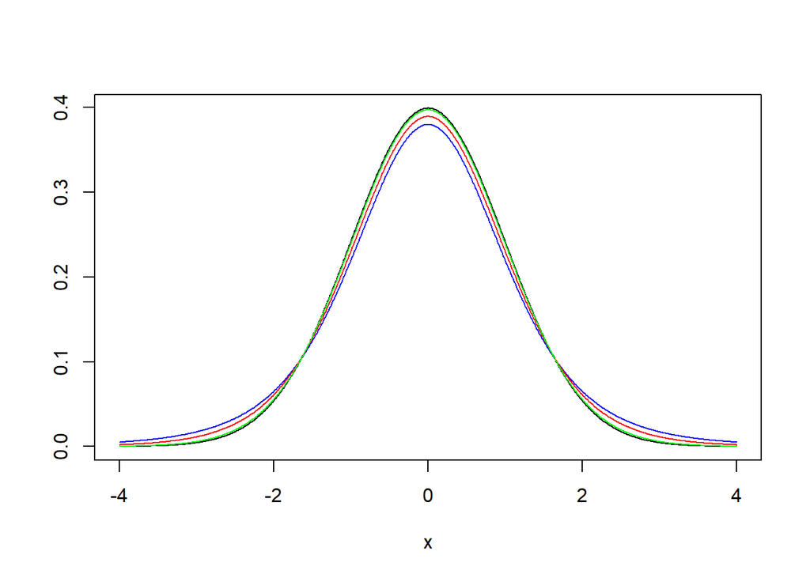

```r
x=seq(-4,4,0.01)
plot(x,dnorm(x,0,1),type='l',ylab='')
lines(x,dt(x,5),col='blue')          #  5 degrees of freedom
lines(x,dt(x,10),col='red')          # 10 degrees of freedom
lines(x,dt(x,50),col='green')        # 50 degrees of freedom
```

$~$

#### 8.1.2.2 Exercise

Suppose a supermarket sells potatoes in 1 kilo bags. We buy 7 bags and weigh them. We find 983, 1041, 1026, 1025, 1033, 968 and 1028 (grams). Suppose that we do **not** know the standard deviation of the weight. We want to test
$$H_0 : \mu = 1000 \quad \text{versus}\quad A : \mu \neq 1000$$
at level $\alpha=0.05$.

1. Compute the $t$ statistic.
2. What is the critical value for your test statistic?
3. Do you reject the null hypothesis?
4. Use simulation to compute the power when true mean weight is actually 980 grams?

**Click for the answer**

```r
x=c(983,1041,1026,1025,1033,968,1028)
t=sqrt(7)*(mean(x)-1000)/sd(x)            # n=7, now estimate the sd!
t
```

```
## [1] 1.416135
```

2. So far, we determined the critical value K by trial-and-error. Here we use the quantile function:

If H0 is true, then t has the t distribution with n-1=6 degrees of freedom. - If |t| < K then we do *not* reject - So, we want P(|t| < K)=0.95, when t distribution with n-1=6 degrees of freedom. - So, we want P(t < K)=0.975, when t distribution with n-1=6 degrees of freedom. - So, K=qt(0.975,6)

```r
K=qt(0.975,6)
K
```

```
## [1] 2.446912
```

3. Since |t|=1.42 is less than K=qt(0.975,6)=2.45, we do NOT reject.

```r
s=sd(x)
reject=0
for (i in 1:10000){
  x=rnorm(7,980,s)                   # use the estimated sd
  t=sqrt(7)*(mean(x) - 1000)/sd(x)   # estimate the sd of the simulated data
  reject = reject + (abs(t) > 2.45)
}
reject/10000                         # power
```

```
## [1] 0.3657
```

$~$

### 8.1.3 $t$ test for difference of two means

We have used the $t$ test to test if the mean is equal to some fixed value. The $t$ test can also be used to test if the means of two populations differ.

Suppose we have a new drug that aims to lower blood pressure. Suppose that we have 35 patients with high blood pressure. We randomly select 20 patients to receive tablets to lower their blood pressure. The remaining 15 patients receive a placebo (inert tablets). Neither the patients nor the doctors know which patients receive the drug.

#### 8.1.3.1 Exercise

What is the purpose of

1. having a control group (the 15 patients)?
2. giving the controls placebo?
3. blinding the patients?
4. blinding the physician?

**Click for the answer**

1. Perhaps everybody gets better or worse in time, if you give the medication or not. The controls allow us to compare to what happens if we do nothing.
2. We want to account for the psycho-somatic effect that giving any pill will make patients feel better.
3. We blind the patients because if patients know they got placebo, they will automatically feel worse.
4. We blind the physician because otherwise (consciously or sub-consciously) the physician might influence the patients.

$~$

Let us generate a fake data set of measurements after two weeks of treatment. We arrange it so that there is indeed a difference between the two groups in the mean blood pressure.

```r
set.seed(123)
x = rnorm(20,140,3)  #20 patients with mean 140 mmHg systolic and standard deviation 3
y = rnorm(15,142,3)  #15 controls with mean 142 mmHg systolic and standard deviation 3
```

We can compare the two groups using a boxplot.

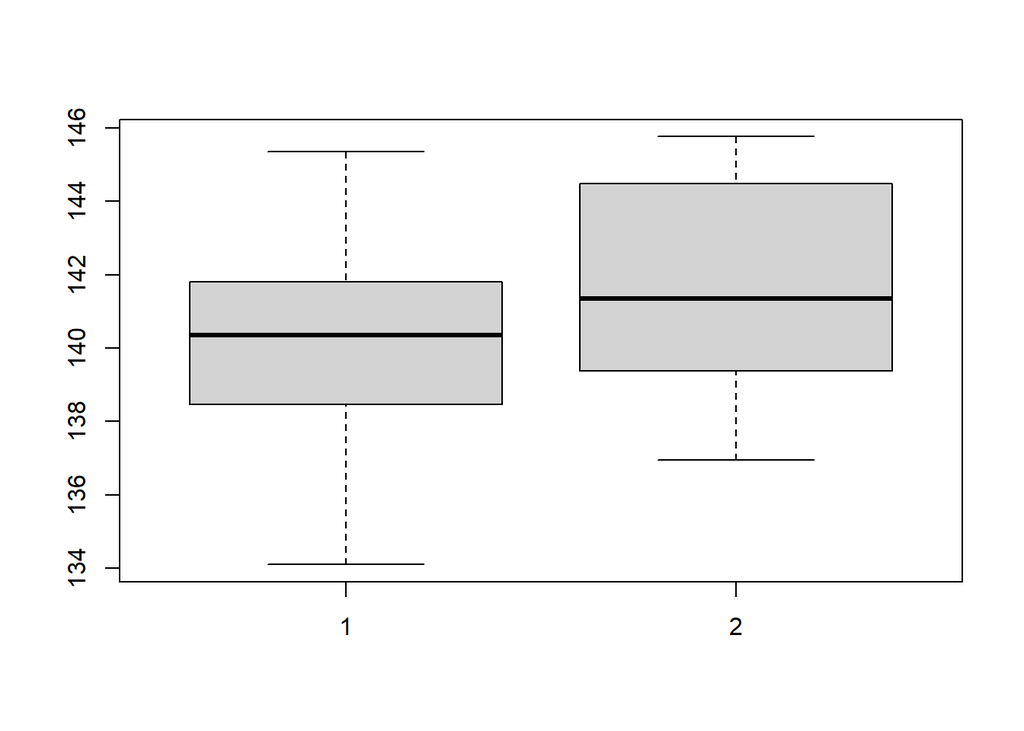

```r
boxplot(list(x,y))
```

Boxplots are quite useful for a quick look. They show the median and the 25% en 75% quantiles as a `box''. The`whiskers’’ show the most extreme values. Essentially, ${\tt boxplot(x)}$ conveys the same information as ${\tt summary(x)}$.

Formally, we have the following problem. Suppose $X_1,X_2,...,X_n$ are normally distributed with mean $\mu_X$ and unknown variance $\sigma^2$. Suppose $Y_1,Y_2,...,Y_m$ are normally distributed with mean $\mu_X$ and the same, but unknown variance $\sigma^2$. We want to test

$$H_0 : \mu_X=\mu_Y\quad {\rm versus}\quad A: \mu_X \neq \mu_Y.$$

We use as our test statistic
$$T = \frac{\bar X - \bar Y}{S_p\sqrt{\frac1n + \frac1m}},$$
where
$$S_p^2 = \frac{(n-1)S^2_X + (m-1)S^2_Y}{m+n-2},$$
with
$$S^2_X = \frac{1}{n-1}\sum_{i=1}^n (X_i - \bar X)^2\quad{\rm and}\quad S^2_Y = \frac{1}{m-1}\sum_{i=1}^m (Y_i - \bar Y)^2.$$
Under the null hypothesis, $T$ has the $t$ distribution with $n+m-2$ degrees of freedom. We choose some critical value $K$ and reject the null hypothesis if $|T|$ exceeds $K$.

#### 8.1.3.2 Exercise

Use the data you generated above. Suppose we want to test at level $\alpha=0.05$. Use ${\tt qt}$ to determine the critical value $K$ and carry out the test.

**Click for the answer**

```r
set.seed(123)
x = rnorm(20,140,3)  #20 patients with mean 140 mmHg systolic and standard deviation 3
y = rnorm(15,142,3)  #15 controls with mean 142 mmHg systolic and standard deviation 3
n=length(x)
m=length(y)
S2x=var(x)
S2y=var(y)
S2p=((n-1)*S2x + (m-1)*S2y)/(n+m-2)
t=(mean(x) - mean(y))/(sqrt(S2p)*sqrt(1/n + 1/m))
t
```

```
## [1] -1.302519
```

compare to

```r
K=qt(0.975,n+m-2)
K
```

```
## [1] 2.034515
```

Since |t|=1.3 is less than K=2.0 we do not reject.

$~$

#### 8.1.3.3 Exercise

Carry out the test a few times with different $n,m,\mu_1,\mu_2$ and $\sigma^2$ making boxplots each time you generate a new data set.

**Click for the answer**

The point is that the t.test compares the difference between the groups to the differences within the groups.

$~$

#### 8.1.3.4 Exercise

Again, generate data by

```r
set.seed(123)
x = rnorm(20,140,3)
y = rnorm(15,142,3)
```

Now perform a *one-sided* t-test of
$$H_0 : \mu_x=\mu_y\quad {\rm versus}\quad A: \mu_x < \mu_y.$$
at level $\alpha=0.05$.

**Click for the answer**

```r
n=length(x)
m=length(y)
S2x=var(x)
S2y=var(y)
S2p=((n-1)*S2x + (m-1)*S2y)/(n+m-2)
t=(mean(x) - mean(y))/(sqrt(S2p)*sqrt(1/n + 1/m))
t
```

```
## [1] -1.302519
```

Now we reject H0 if t is *small*. We compare to

```r
qt(0.05,n+m-2)
```

```
## [1] -1.69236
```

Since t=-1.3 is larger than qt(0.05,n+m-2)=-1.69, we do not reject.

$~$

### 8.1.4 Unfamiliar tests

The chi-squared test, $z$-test and $t$-test are very often used in practice. But the *principle* of hypothesis testing is much more general and can be applied in many different situations. Now, let’s consider some *unfamiliar* tests.

#### 8.1.4.1 Exercise

Suppose we have a sample of size $n = 5$ from the normal distribution with mean $\mu = 0$ and unknown standard deviation $\sigma$. Suppose we decide to test
$$H_0 : \sigma = 2 \quad {\rm versus}\quad A: \sigma > 2.$$

by computing the sample standard deviation $S$, and rejecting $H_0$ if $S$ is greater than 2. Use simulation to answer the following questions.

1. What is the level of significance of this test.
2. What is the power of the test against the alternative $\sigma = 3$?
3. Use trial-and-error to find the critical value so that the test has level 5%.
4. An alternative approach to trial-and-error is as follows. Simulate the test statistic many times under the null hypothesis. Then use the R function `quantile` to get the value which is exceeded by 95% of the sample.

**Click for the answer**

```r
# a.
reject=0
for (i in 1:10000){
x=rnorm(5,0,2)
reject=reject + (sd(x)>2)
}
reject/10000 # 0.40 (approximately)
```

```
## [1] 0.4079
```

```r
# b.
reject=0
for (i in 1:10000){
x=rnorm(5,0,3)
reject=reject + (sd(x)>2)
}
reject/10000 # 0.77 (approximately)
```

```
## [1] 0.7705
```

```r
# c.
reject=0
for (i in 1:10000){
x=rnorm(5,0,2)
reject=reject + (sd(x)>3.08)
}
reject/10000 # 0.05 (approximately)
```

```
## [1] 0.0494
```

```r
# d
stat=rep(0,10000)
for (i in 1:10000){
x=rnorm(5,0,2)
stat[i]=sd(x)
}
quantile(stat,probs=0.95)
```

```
##      95%
## 3.104163
```

$~$

#### 8.1.4.2 Exercise

Suppose we have a random sample of size $n$ = 12 and want to test the (null) hypothesis that they were drawn from the normal distribution with mean 1 and standard deviation 1 versus the alternative that they were drawn from the exponential distribution with mean 1. We know that the normal distribution is symmetric, so that the (population) mean and de median are equal. The exponential distribtuion, however, is skewed to the right so that the mean is larger than the median. So, we decide to use the following test: Compute the sample mean $\bar x$ and the sample median $m$, and reject the null hypothesis if $\bar x - m > 0.3$.

You should use simulation to answer the following questions. You can use the R functions ${\tt median}$ to compute the median and ${\tt rnorm}$ and ${\tt rexp}$ to generate random samples.

1. What is the significance level of the test?
2. What is the probability of a type II error?
3. What is the power against the alternative?
4. Below are the 12 random numbers, rounded to two decimals. Do you reject the null hypothesis?

```r
x=c(1.01, 2.87, 0.93, 0.52, 0.61, 3.37, 2.07, 0.62, 0.72, 0.52, 1.31, 0.91)
```

**Click for the answer**

Note that N(1,1) and Exp(1) have the same mean and variance. However, the exponential distribution is more skewed than the normal and this should be noticeable as a difference between the mean and the median. If you’re interested, the median of N(1,1) is 1 (equal to the mean) and the median of Exp(1) is log(2)=0.69.

```r
# a.
count=0
for (i in 1:10000){
x=rnorm(12,1,1)
count = count + (mean(x)-median(x) > 0.3)
}
count/10000 # about 0.05
```

```
## [1] 0.0516
```

```r
#
# b.
count=0
for (i in 1:10000){
x=rexp(12,1)
count = count + (mean(x)-median(x) < 0.3) # fail to reject
}
count/10000 # about 0.61
```

```
## [1] 0.6166
```

3. The power is one minus the probability of a type II error

```r
x=c(1.01, 2.87, 0.93, 0.52, 0.61, 3.37, 2.07, 0.62, 0.72, 0.52, 1.31, 0.91)
mean(x) - median(x) # 0.368 which is larger than 0.3, so reject.
```

```
## [1] 0.3683333
```

$~$

## 8.2 Confidence interval

A confidence interval is a set of parameter values that are compatible with the data to some degree. We can formalize this rather vague notion by using hypothesis tests.

Consider the coin tossing example again, where we can test
$$H_0 : p=p_0\quad {\rm versus}\quad A: p \neq p_0.$$

at some level $\alpha$. We have done the test for $p_0=1/2$, but we can do it for *any* value of $p_0$ between 0 and 1:
$$\begin{align*}
&H_0 : p=0.01 \quad \text{versus} \quad A: p \neq 0.01 \\
&H_0 : p=0.02 \quad \text{versus} \quad A: p \neq 0.02 \\
&H_0 : p=0.03 \quad \text{versus} \quad A: p \neq 0.03 \\
&\dots \\
&H_0 : p=0.99 \quad \text{versus} \quad A: p \neq 0.99 \\
\end{align*}$$

If we do all these tests, then we can list the ones that we do not reject. That is called a $(1 - \alpha ) \times 100\%$ confidence interval.

Recall that we got 140 heads out of 250 tosses, We will use the normal approximation for the binomial test to make the computations easy.

```r
x=140
n=250
p0=seq(0.05,0.95,0.05)
z=(x - n*p0)/sqrt(n*p0*(1-p0))
reject=abs(z)>1.96
cbind(p0,z,reject)
```

```
##         p0           z reject
##  [1,] 0.05  36.9992888      1
##  [2,] 0.10  24.2441287      1
##  [3,] 0.15  18.1551052      1
##  [4,] 0.20  14.2302495      1
##  [5,] 0.25  11.3195995      1
##  [6,] 0.30   8.9708523      1
##  [7,] 0.35   6.9614322      1
##  [8,] 0.40   5.1639778      1
##  [9,] 0.45   3.4960295      1
## [10,] 0.50   1.8973666      0
## [11,] 0.55   0.3178209      0
## [12,] 0.60  -1.2909944      0
## [13,] 0.65  -2.9834709      1
## [14,] 0.70  -4.8304589      1
## [15,] 0.75  -6.9378191      1
## [16,] 0.80  -9.4868330      1
## [17,] 0.85 -12.8414158      1
## [18,] 0.90 -17.9195734      1
## [19,] 0.95 -28.2935738      1
```

We get a very rough indication of the confidence interval. It runs from about 0.5 to 0.6. We can get a more precise result if we make the step size smaller.

#### 8.2.0.1 Exercise

Repeat the computation with step size 0.001. What are the lower and upper bounds of the confidence interval? Of course, you can just check your output but it’s nicer to use R to get those bounds!

**Click for the answer**

```r
x=140
n=250
p0=seq(0.495,0.625,0.001)
z=(x - n*p0)/sqrt(n*p0*(1-p0))
reject=abs(z)>1.96
cbind(p0,z,reject)
```

```
##           p0           z reject
##   [1,] 0.495  2.05558326      1
##   [2,] 0.496  2.02392247      1
##   [3,] 0.497  1.99227079      1
##   [4,] 0.498  1.96062783      1
##   [5,] 0.499  1.92899323      0
##   [6,] 0.500  1.89736660      0
##   [7,] 0.501  1.86574755      0
##   [8,] 0.502  1.83413572      0
##   [9,] 0.503  1.80253071      0
##  [10,] 0.504  1.77093216      0
##  [11,] 0.505  1.73933968      0
##  [12,] 0.506  1.70775290      0
##  [13,] 0.507  1.67617143      0
##  [14,] 0.508  1.64459490      0
```

[output cut: 117 more lines]

```r
# The confidence interval is about 0.499 to 0.620
```

$~$

#### 8.2.0.2 Exercise

Repeat the previous Exercise, but change the level of significance to see what happens.

**Click for the answer**

If you increase the level of significance (say to 10%) the confidence interval becomes more narrow. Now you allow 10% probability to “miss” the true value.

If you decrease the level of significance (say to 1%) the confidence interval becomes more wide. Now you allow only 1% probability to “miss” the true value.

$~$

#### 8.2.0.3 Exercise

Repeat the previous Exercise, but change the number of tosses $n$ and the number of heads $X$ to see what happens.

**Click for the answer**

```r
x=1400
n=2500
p0=seq(0.495,0.625,0.001)
z=(x - n*p0)/sqrt(n*p0*(1-p0))
reject=abs(z)>1.96
cbind(p0,z,reject)
```

```
##           p0             z reject
##   [1,] 0.495  6.500325e+00      1
##   [2,] 0.496  6.400205e+00      1
##   [3,] 0.497  6.300113e+00      1
##   [4,] 0.498  6.200050e+00      1
##   [5,] 0.499  6.100012e+00      1
##   [6,] 0.500  6.000000e+00      1
##   [7,] 0.501  5.900012e+00      1
##   [8,] 0.502  5.800046e+00      1
##   [9,] 0.503  5.700103e+00      1
##  [10,] 0.504  5.600179e+00      1
##  [11,] 0.505  5.500275e+00      1
##  [12,] 0.506  5.400389e+00      1
##  [13,] 0.507  5.300519e+00      1
##  [14,] 0.508  5.200666e+00      1
```

[output cut: 117 more lines]

The confidence interval is about 0.541 to 0.579. So if we have more data, then the confidence interval becomes more narrow This makes sense; with more data we have more certainty.

$~$

Doing all the tests and checking the rejections is not the smartest way to compute a confidence interval. In simple cases, it is much better to use mathematics. So, we do *not* reject the null hypothesis if
$$|Z| = \left| \frac{X - np_0}{\sqrt{np_0(1-p_0)}} \right| < 1.96$$
But this is *approximately* the same as
$$|Z| = \left| \frac{X - np_0}{\sqrt{n \hat p(1-\hat p)}} \right| < 1.96$$
where $\hat p = X/n$ is our estimator. Now we can solve for $p_0$ and find that we do not reject if
$$\hat p - 1.96 \sqrt{\hat p(1-\hat p)/n} < p_0 < \hat p + 1.96 \sqrt{\hat p(1-\hat p)/n}$$

#### 8.2.0.4 Exercise

Compute the confidence interval for the Polish experiment using the formula above, and compare to the previous Exercises.

**Click for the answer**

```r
x=140
n=250
p=140/250
lower=p - 1.96 * sqrt(p*(1-p)/n)
lower
```

```
## [1] 0.4984672
```

```r
upper=p + 1.96 * sqrt(p*(1-p)/n)
upper
```

```
## [1] 0.6215328
```

$~$

If you did the previous exercise correctly, you will have found that the value 0.5 is in the 95% confidence interval. This makes perfect sense since the confidence interval consists of all parameter values that are *not* rejected at the 5% level, and we already know that we do not reject the hypothesis of a fair coin at that level.

#### 8.2.0.5 Exercise

We can also compute a 90% confidence interval. Or a 99% confidence interval. Which one is wider? Compute them both for the Polish experiment.

**Click for the answer**

```r
x=140
n=250
p=140/250


# 90% CI
lower=p - qnorm(0.95) * sqrt(p*(1-p)/n)
lower
```

```
## [1] 0.508361
```

```r
upper=p + qnorm(0.95) * sqrt(p*(1-p)/n)
upper
```

```
## [1] 0.611639
```

```r
# 99% CI
lower=p - qnorm(0.995) * sqrt(p*(1-p)/n)
lower
```

```
## [1] 0.4791337
```

```r
upper=p + qnorm(0.995) * sqrt(p*(1-p)/n)
upper
```

```
## [1] 0.6408663
```

$~$

### 8.2.1 Coverage

When we do a test at significance level $\alpha$, we are making sure that the probability of rejecting the null hypothesis when it is true is not more than $\alpha$. So, this means that the probability that the confidence interval does *not* contain the true value is not more than $\alpha$. In other words, the probability that the confidence interval does contain the true value is at least $1 - \alpha$. This is then called the coverage probability. Let’s verify this claim.

#### 8.2.1.1 Exercise

Choose some number $n$ and some probability $p$. Use ${\tt rbinom}$ to generate a sample $x$ from the binomial distribution, and construct the 95% confidence interval. Check if the true $p$ (the one that you used to sample $X$) is in the confidence interval. Now repeat 10,000 times and check if this happened about 95% of the time.

**Click for the answer**

```r
n=200
p0=0.4  # the true prob of succes

cover=0
for (i in 1:10000){
  x=rbinom(1,n,p0)
  p=x/n
  lower=p - qnorm(0.975) * sqrt(p*(1-p)/n)
  upper=p + qnorm(0.975) * sqrt(p*(1-p)/n)
  cover = cover + ((lower < p0) & (upper > p0))
}
cover/10000
```

```
## [1] 0.9523
```

$~$

#### 8.2.1.2 Exercise

Repeat the previous exercise with the 90% confidence interval.

**Click for the answer**

```r
n=200
p0=0.3  # the true prob of succes

cover=0
for (i in 1:10000){
  x=rbinom(1,n,p0)
  p=x/n
  lower=p - qnorm(0.95) * sqrt(p*(1-p)/n)
  upper=p + qnorm(0.95) * sqrt(p*(1-p)/n)
  cover = cover + ((lower < p0) & (upper > p0))
}
cover/10000
```

```
## [1] 0.909
```

$~$

Coverage is often misunderstood, so it’s very important to understand what it really means. The parameter is unknown, but it is *fixed*. The confidence interval is what’s random. It “hits” the unknown parameter with probability $1-\alpha$.

Note that a *realized* confidence interval is not random anymore. So *all* we can say is that must have hit or not hit the unknown parameter, but we cannot assign a probability to that.

For example, suppose we have a sample of size $n=200$ from the binomial distribution with unknown parameter $p$. Let’s compute 40 95% confidence intervals when $p=0.3$. We would expect about 2 of those (i.e. 5% of 40) to miss. It’s helpful to think of the following picture

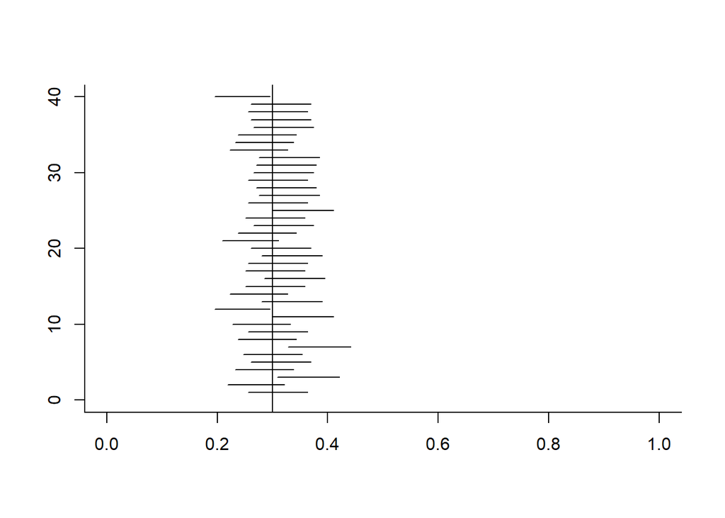

Now, let’s compute some more confidence intervals.

#### 8.2.1.3 Exercise

Suppose a supermarket sells potatoes in 1 kilo bags. We buy 7 bags and weigh them. We find 983, 1041, 1026, 1025, 1033, 968 and 1028 (grams). We know that the standard deviation of the weight is 25 grams. Test
$$H_0 : \mu = \mu_0 \quad \text{versus}\quad A : \mu \neq \mu_0$$
at level $\alpha=0.05$ for all values of $\mu$ between 950 and 1050 at stepsize 1. Which values of $\mu_0$ do you *not* reject?

**Click for the answer**

```r
x=c(983, 1041, 1026, 1025, 1033, 968, 1028)

mu0=seq(950,1050,1)
z=sqrt(7)*(mean(x) - mu0)/25  # the Z-statistic
reject=abs(z)>1.96
cbind(mu0,z,reject)
```

```
##         mu0           z reject
##   [1,]  950  6.86383483      1
##   [2,]  951  6.75800478      1
##   [3,]  952  6.65217472      1
##   [4,]  953  6.54634467      1
##   [5,]  954  6.44051462      1
##   [6,]  955  6.33468457      1
##   [7,]  956  6.22885452      1
##   [8,]  957  6.12302446      1
##   [9,]  958  6.01719441      1
##  [10,]  959  5.91136436      1
##  [11,]  960  5.80553431      1
##  [12,]  961  5.69970425      1
##  [13,]  962  5.59387420      1
##  [14,]  963  5.48804415      1
```

[output cut: 87 more lines]

```r
# lower = 997
# upper = 1033
```

$~$

#### 8.2.1.4 Exercise

Show that the 95% confidence interval for the mean $\mu$ of a normal distribution with known standard deviation $\sigma$ is given by
$$\bar X - 1.96 \sigma/\sqrt{n} < \mu < \bar X + 1.96 \sigma/\sqrt{n}$$

Use the formula to compute the confidence interval, and compare to the previous exercise.

**Click for the answer**

The confidence interval consists of all values mu0 that are NOT rejected when testing

$~$

H0: mu=mu0 versus A: mu is not mu0

$~$

Let X.bar be the average of X1,..,Xn, and sigma the (known) standard deviation. We do NOT reject H0 if $\sqrt{n} |\bar x - \mu_0|/\sigma < 1.96$. Now, solving for mu0 we obtain the confidence interval.

```r
x=c(983, 1041, 1026, 1025, 1033, 968, 1028)
lower = mean(x) - qnorm(0.975)*25/sqrt(7)
lower
```

```
## [1] 996.3372
```

```r
upper = mean(x) + qnorm(0.975)*25/sqrt(7)
upper
```

```
## [1] 1033.377
```

$~$

#### 8.2.1.5 Exercise

Give the formula for the 80% confidence interval for the mean $\mu$ of a normal distribution with known standard deviation $\sigma$.

**Click for the answer**

Let X.bar be the average of X1,..,Xn, and sigma the (known) standard deviation. The 80% confidence interval is

```r
lower = X.bar - qnorm(0.9)*sigma/sqrt(n) = X.bar - 1.28*sigma/sqrt(n)
upper = X.bar + qnorm(0.9)*sigma/sqrt(n) = X.bar - 1.28*sigma/sqrt(n)
```

$~$

#### 8.2.1.6 Exercise

Suppose a supermarket sells potatoes in 1 kilo bags. We buy 7 bags and weigh them. We find 983, 1041, 1026, 1025, 1033, 968 and 1028 (grams). Unfortunately, we do *not* know the standard deviation. Use the t-test to test
$$H_0 : \mu = \mu_0 \quad \text{versus}\quad A : \mu \neq \mu_0$$
at level $\alpha=0.05$ for all values of $\mu$ between 950 and 1050 at stepsize 1. Which values of $\mu_0$ do you *not* reject?

**Click for the answer**

```r
x=c(983, 1041, 1026, 1025, 1033, 968, 1028)

mu0=seq(950,1050,1)
t=sqrt(7)*(mean(x) - mu0)/sd(x)  # the t-statistic
reject=abs(t)>qt(0.975,6)        # critical value for t-distr with 6 D.F.
cbind(mu0,t,reject)
```

```
##         mu0           t reject
##   [1,]  950  6.18197467      1
##   [2,]  951  6.08665788      1
##   [3,]  952  5.99134109      1
##   [4,]  953  5.89602430      1
##   [5,]  954  5.80070751      1
##   [6,]  955  5.70539072      1
##   [7,]  956  5.61007393      1
##   [8,]  957  5.51475714      1
##   [9,]  958  5.41944035      1
##  [10,]  959  5.32412356      1
##  [11,]  960  5.22880677      1
##  [12,]  961  5.13348998      1
##  [13,]  962  5.03817319      1
##  [14,]  963  4.94285640      1
```

[output cut: 87 more lines]

```r
# lower = 990
# upper = 1040
```

$~$

#### 8.2.1.7 Exercise

Show that the 95% confidence interval in the previous exercise is given by
$$\bar X - 2.45 S/\sqrt{7} < \mu < \bar X + 2.45 S/\sqrt{7}$$
where $S$ is the sample standard deviation of the 7 bags. Then use the formula to compute the confidence interval, and compare to the previous exercise.

**Click for the answer**

The confidence interval consists of all values mu0 that are NOT rejected when testing

$~$

H0: mu=mu0 versus A: mu is not mu0

$~$

Let X.bar be the average of X1,..,Xn, and S the sample standard deviation.

We do NOT reject H0 if |t| = sqrt(n) * |x.bar - mu0|/S < 2.45 where qt(0.975,6)=2.45. Now, solving for mu0 we obtain the confidence interval.

```r
x=c(983, 1041, 1026, 1025, 1033, 968, 1028)
lower = mean(x) - qt(0.975,6)*sd(x)/sqrt(7)
lower
```

```
## [1] 989.1858
```

```r
upper = mean(x) + qt(0.975,6)*sd(x)/sqrt(7)
upper
```

```
## [1] 1040.529
```

$~$

#### 8.2.1.8 Exercise

What is the 85% confidence interval for the mean weight of the 7 bags?

**Click for the answer**

```r
x=c(983, 1041, 1026, 1025, 1033, 968, 1028)
n=7
lower = mean(x) - qt(0.925,n-1)*sd(x)/sqrt(n)
lower
```

```
## [1] 997.5446
```

```r
upper = mean(x) + qt(0.925,n-1)*sd(x)/sqrt(n)
upper
```

```
## [1] 1032.17
```

## 8.3 What have we learned

- We know some standard tests, and can apply non-standard tests
- We know that a confidence interval is a set of parameter values that are compatible with the data to some degree.
- We know that a confidence interval is a set of parameter values that are *not* rejected at some particular level of significance.
- We can compute confidence intervals in standard situations.

$~$

# 9 Tests based on likelihood

We have learned general recipes for performing a hypothesis test based on a tests statistic, but how do we come up with a test statistic? That is what this lecture is about.

## 9.1 Is any test statistic fine?

All we need to be able to do an hypothesis test is a test-statistic (= a number that can be computed from data) which tends to become large when the true distribution of the data is further from the null hypothesis. In many cases it is obvious which statistic we should use, but in many more cases it is not!

Suppose we have a sample $X_1,X_2,\dots,X_n$ from the normal distribution with mean 0 and unknown variance $\sigma^2$. We want to test
$$H_0: \sigma^2 = 1 \quad \text{versus} \quad A: \sigma^2 > 1.$$
As test statistic we can use *any* measure of variability in the data. Here are just a few:

- the sample variance $S^2 = \frac{1}{n-1} \sum_{i=1}^n (X_i - \bar X)^2$
- the MLE $\hat\sigma^2 = \frac{1}{n} \sum_{i=1}^n (X_i - \bar X)^2$
- the mean absolute deviation $\text{MAD} = \frac1n \sum_{i=1}^n |X_i - \bar X|$
- the range $\max(X_1,X_2,\dots,X_n) - \min(X_1,X_2,\dots,X_n)$
- the interquartile range (IQR), which is the difference between the 75% and 25% quantiles.

All of these can be used to construct a hypothesis test. We simply follow the general recipe we learned in the previous lecture. To test some null hypothesis at significance level $\alpha$ we:

> 1. Choose a *test statistic* $T$, a random variable that you expect to have large values if the null hypothesis is false, and small values if the null hypothesis is true.
> 2. Find the distribution of $T$ under the null hypothesis, either analytically or by simulation.
> 3. Find $t_\alpha$, the $(1-\alpha)$-quantile of the distribution of $T$.
> 4. If the observed $T$ is larger than $t_\alpha$, reject the null hypothesis.

Of course an $\alpha$-level must be chosen as well. If the $\alpha$-level is not mentioned in an exercise, use $\alpha=0.05$.

$~$

#### 9.1.0.1 Exercise

Suppose we use the range $\max(X_1,X_2,\dots,X_n) - \min(X_1,X_2,\dots,X_n)$ as the test statistic for testing $H_0: \sigma^2 = 1 \quad \text{versus} \quad A: \sigma^2 > 1$. Suppose also that $n=6$.

1. Use simulation to find the critical value for testing at significance level $\alpha=0.05$.
2. Suppose we observe $X = (2.0, 2.9, -0.5, 0.3, -0.8, -0.1)$. Do we reject the null hypothesis?

**Click for the answer**

```r
X = c(2.0,  2.9, -0.5,  0.3, -0.8, -0.1)
N <- length(X)
# simulate test statistics under H0
null_statistics <- replicate( 1e5, {
  X <- rnorm(N, 0, 1)
  diff(range(X))      # same as max(X) - min(X)
})
critical_value <- quantile(null_statistics, 0.95)
critical_value
```

```
##      95%
## 4.023349
```

```r
observed_statistic <- diff(range(X))
observed_statistic
```

```
## [1] 3.7
```

Since the observed statistic 3.7 does not exceed than the critical value of 4.0 we do not reject $H_0$.

$~$

In this recipe, steps 2-4 are relatively straightforward. Given $T$, we know what to do to obtain its distribution and its quantile. Step 1, in contrast, requires some thinking. What test statistic should we choose? Are some test statistics better than others? What is a good way to choose a test statistic? Those are the question we will discuss in this lecture.

$~$

#### 9.1.0.2 Exercise

Explain what *valid* and *powerful* mean in this sense. Can you give an example of a test that is always valid, but never powerful?

**Click for the answer**

Valid means not exceeding the type I error rate set. Powerful means having large power against alternatives we are interested in detecting. A test that is always valid but never powerful is e.g. a test that never rejects. Such a test has type I error and power 0. More subtly, it could be a test that tosses a coin and rejects with probability $\alpha$, irrespective of the data. Such a test has type I error $\alpha$ and power $\alpha$, whatever the alternative.

$~$

#### 9.1.0.3 Exercise

Calculate the power of the test with $N=6$ for testing $H_0: \sigma^2 = 1 \quad \text{versus} \quad A: \sigma^2 > 1$ with test statistic $T= \max(X_1,X_2,\dots,X_n) - \min(X_1,X_2,\dots,X_n)$, when the true value of $\sigma^2$ is 2.

**Click for the answer**

```r
# from the previous exercise, we have the critical value
critical_value <- 4.02

# get power: simulate test statistics under the alternative
alt_statistics <- replicate( 1e5, {
  X <- rnorm(N, 0, sqrt(2))
  diff(range(X))
})
power <- mean(alt_statistics > critical_value)
power
```

```
## [1] 0.33793
```

$~$

#### 9.1.0.4 Exercise

Now let’s use the sample variance as our test statistic instead of the range to testing $H_0: \sigma^2 = 1 \quad \text{versus} \quad A: \sigma^2 > 1$. again, suppose the sample size is $N=6$.

1. Use simulation to calculate the critical value for the testing at significance level 5%
2. Use simulation to calculate the power of the test, when the true value of $\sigma^2$ is 2.

**Click for the answer**

```r
# a
N <- 6
# get critical value: simulate test statistics under H0
null_statistics <- replicate( 1e5, {
  X <- rnorm(N, 0, 1)
  var(X)
})
critical_value <- quantile(null_statistics, 0.95)
critical_value
```

```
##      95%
## 2.228841
```

```r
# b.
# get power: simulate test statistics under the alternative
alt_statistics <- replicate( 1e5, {
  X <- rnorm(N, 0, sqrt(2))
  var(X)
})
power <- mean(alt_statistics > critical_value)
power
```

```
## [1] 0.34971
```

$~$

To get a *valid* test, any test statistic will do. To get a very *powerful* test, some test statistics are better choices than others. In this particular example above, $S^2$ and $\hat\sigma^2$ are the best choices. It can be shown mathematically that for the same level of significance, the resulting tests have greater power than any of the other choices against any alternative.

So, some test statistics are simply better than others – they are better at summarizing the pertinent information into a single number. In this section we describe general methods for finding good test statistics. We will use the likelihood to find them.

## 9.2 Equivalent tests

Some tests look very different but they are actually the same. We call two test statistics $S$ and $T$ *equivalent* if the test of level $\alpha$ that rejects for large values of $S$ and the test that rejects for large values of $T$ always give the same result: either both reject or both don’t reject.

$~$

#### 9.2.0.1 Exercise

Suppose that for $H_0: \sigma^2=1$ versus $A: \sigma^2>1$ the test that rejects $H_0$ when $S^2 > k_\alpha$ as level $\alpha$. Show that the test for $H_0$ against $A$ that rejects when $S > \sqrt{k_\alpha}$ also has level $\alpha$. Show that the two tests either both rejects or both don’t reject. Are $S$ and $S^2$ equivalent test statistics?

**Click for the answer**

If the test that rejects when $S^2 > k_\alpha$ has level $\alpha$, that means that under $H_0$,
$$\mathrm{P}(S^2 > k_\alpha) = \alpha.$$
Since $S^2 > k_\alpha$ if and only if $S > \sqrt{k_\alpha}$, we also have
$$\mathrm{P}(S > \sqrt{k_\alpha}) = \alpha.$$
Since $S^2 > k_\alpha$ if and only if $S > \sqrt{k_\alpha}$, either both of the tests reject or both don’t reject. We conclude that $S$ and $S^2$ are equivalent.

$~$

#### 9.2.0.2 Exercise

Show that for $H_0: \sigma^2=1$ versus $A: \sigma^2>1$, $S^2$ and $\hat\sigma^2 = \frac{1}{n} \sum_{i=1}^n (X_i - \bar X)^2$ are equivalent test statistics.

**Click for the answer**

Let $k_\alpha$ be the critical value for $S^2$, so the test that rejects when $S^2 > k_\alpha$ has level $\alpha$, that means that under $H_0$,
$$\mathrm{P}(S^2 > k_\alpha) = \alpha.$$
Since
$$(n-1)S^2 = \sum_{i=1}^n (X_i - \bar X)^2 = n\hat\sigma^2,$$
so $(n-1)S^2/n = \hat\sigma^2$. We have that $S^2 > k_\alpha$ if and only if $(n-1)S^2 > (n-1)k_\alpha$ if and only if $(n-1)S^2/n > (n-1)k_\alpha/n$, so $\hat\sigma^2 > (n-1)k_\alpha/n$. Therefore, under $H_0$,
$$\mathrm{P}\big(\hat\sigma^2 > (n-1)k_\alpha/n\big) = \alpha,$$
so $(n-1)k_\alpha/n$ is the critical value of $\hat\sigma^2$. Since $S^2 > k_\alpha$ if and only if $\hat\sigma^2 > (n-1)k_\alpha/n$, either both of the tests reject or both don’t reject. We conclude that $S^2$ and $\hat\sigma^2$ are equivalent.

$~$

In general, we have the following simple rule:

> if $f(x)$ is a strictly increasing function, then $T$ and $f(T)$ are equivalent test statistics.

*Strictly increasing* means that if $a > b$, then always $f(a) > f(b)$.

Tests based on equivalent test statistics are essentially different ways of writing the same test: their formulas may look different, but their outcomes are always the same.

$~$

#### 9.2.0.3 Exercise

Apply the rule to the previous two exercises. What is the function $f$ in these cases?

**Click for the answer**

When comparing $S$ and $S^2$, we can take $f(x)=\sqrt{x}$. This is strictly increasing, and $S = f(S^2)$.

When comparing $S^2$ and $\hat\sigma^2$, we can take $f(x) = (n-1)x/n$. This is strictly increasing, and $\hat\sigma^2 = f(S^2)$.

$~$

When defining hypothesis tests, we always assumed that tests would reject for large values of the test statistic $T$. However, there are also two-sided tests (e.g. the $t$-test) that reject not only when $T > a$ but also when $T < -a$. To avoid having to make specific theory on two-sided tests, we remark that the test that rejects when $T > a$ or $T < -a$ is the same as the test that rejects when $T^2 > a^2$. This means we only need to think about one-sided tests. To make a two-sided test, we can simply square the test statistic and do a one-sided test on $T^2$.

## 9.3 Test statistics motivated by likelihood

Finding a good test statistic means for a null hypothesis e.g. $H_0: \theta=\theta_0$ means harnessing as much information as possible about the parameter $\theta$ to show that it is different from 0. The information of the data on $\theta$ is contained in the likelihood of $\theta$. It makes sense to build a test statistic based on this likelihood.

There are three classical ways to make a test statistic based on the likelihood. These are summarized in a figure below. Almost every parametric test you have learned about is a special case of one of these!

- The *Wald test* uses
  $$T_\mathrm{Wald}=\hat\theta -\theta_0.$$
- The *Likelihood Ratio* test uses
  $$T_\mathrm{LRT}=\mathrm{loglik}(\hat\theta) - \mathrm{loglik}(\theta_0).$$
- The *Score* test uses
  $$T_\mathrm{score} = \mathrm{loglik}'(\theta_0).$$

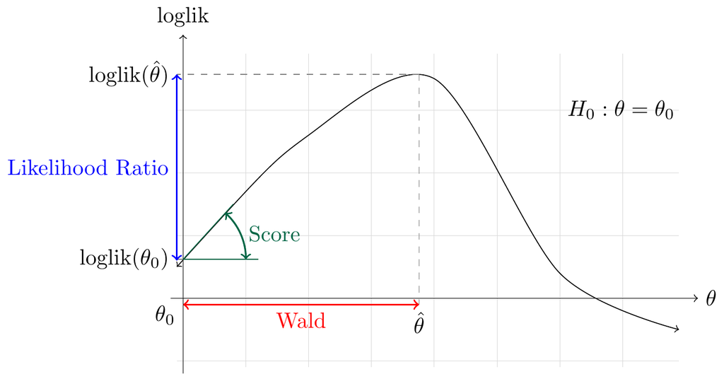

**Figure: the three classical test statistics**

Anytime we can calculate a likelihood, we can define Wald, Score and Likelihood Ratio tests. We can calculate them analytically or numerically.

$~$

#### 9.3.0.1 Exercise

The likelihood ratio statistic is never negative. Why?

**Click for the answer**

Since $\hat\theta$ is the MLE, its likelihood is higher than that of any other $\theta$, so it cannot be less than the likelihood of $\theta_0$.

$~$

#### 9.3.0.2 Exercise

For the Wald, likelihood ratio and score tests statistics, what values do you expect to see if

1. $\theta = \theta_0$;
2. $\theta \gg \theta_0$
3. $\theta \ll \theta_0$.

Here $\ll$ and $\gg$ mean “much smaller than” and “much greater than”.

**Click for the answer**

Wald: (1.) around 0; (2.) $\gg 0$; (3.) $\ll 0$.

Likelihood ratio: (1.) around 0; (2.) $\gg 0$; (3.) $\gg 0$.

Score: (1.) around 0; (2.) $\gg 0$; (3.) $\ll 0$.

$~$

#### 9.3.0.3 Exercise

For the exponential distribution likelihood, calculate the Wald, likelihood ratio and score test statistics for $H_0: \lambda=1$ analytically. You can use the expressions for the likelihood, score and MLE that we derived in previous exercises (see Day 5). Evaluate the test statistic if we have observed $X = (1.0, 5.2, 2.1, 9.3, 0.7, 1.5, 2.5, 0.9, 1.0, 3.8, 6.6, 1.6)$.

**Click for the answer**

We write $\lambda_0=1$ (since we have $H_0: \lambda=1$).

For the Wald test we use that the MLE is $\hat\lambda = 1/\bar X$:
$$T_\mathrm{Wald}=\hat\lambda -\lambda_0 \\ = 1/\bar X - 1.$$

For the likelihood ratio test, we use that the exponential likelihood is
$$\mathrm{loglik}(\lambda) = n\log(\lambda) - \lambda \sum_{i=1}^n x_i\\ = n\log(\lambda) - n\lambda\bar X.$$
We get

$$T_\mathrm{LRT}=\mathrm{loglik}(\hat\lambda) - \mathrm{loglik}(\lambda_0)\\
= n\log(\hat\lambda) - n\hat\lambda\bar X - n\log(\lambda_0) + n\lambda_0\bar X \\
= n\log(1/\bar X) - n(1/\bar X)\bar X - n\log(1) + n\bar X \\
= -n\log(\bar X) - n + n\bar X.$$

For the score test we use that
$$\mathrm{loglik}'(\lambda) = \frac{n}{\lambda} - \sum_{i=1}^n x_i \\ = n/\lambda - n\bar X.$$
We get
$$T_\mathrm{score} = \mathrm{loglik}'(\lambda_0) \\ = n/\lambda_0 - n\bar X \\ = n - n\bar X.$$

```r
X = c(1.0, 5.2, 2.1, 9.3, 0.7, 1.5, 2.5, 0.9, 1.0, 3.8, 6.6, 1.6)
N = length(X)
T_Wald = (1-mean(X))/mean(X)
T_Wald
```

```
## [1] -0.6685083
```

```r
T_LRT = -N * log(mean(X)) - N + N*mean(X)
T_LRT
```

```
## [1] 10.95017
```

```r
T_score = N - N*mean(X)
T_score
```

```
## [1] -24.2
```

$~$

#### 9.3.0.4 Exercise

Suppose we have observed $X = (1.0, 5.2, 2.1, 9.3, 0.7, 1.5, 2.5, 0.9, 1.0, 3.8, 6.6, 1.6)$ from an exponential distribution with unknown $\lambda$. Calculate the Wald, likelihood ratio and score test statistics for $H_0: \lambda=1$ numerically. Use that the MLE $\hat\lambda$ is $1/\bar X$.

**Click for the answer**

```r
X = c(1.0, 5.2, 2.1, 9.3, 0.7, 1.5, 2.5, 0.9, 1.0, 3.8, 6.6, 1.6)
hat_lambda <- 1/mean(X)
lambda0 <- 1

# Wald
T_Wald = hat_lambda- lambda0
T_Wald
```

```
## [1] -0.6685083
```

```r
# LRT
loglik_fun <- function(lambda) sum(dexp(X, rate = lambda, log=TRUE))
T_LRT = loglik_fun(hat_lambda) - loglik_fun(lambda0)
T_LRT
```

```
## [1] 10.95017
```

```r
# score
step=0.0001
lambda_grid <- lambda0 + c(-step/2, step/2)
loglik <- sapply(lambda_grid, loglik_fun)
T_score <- diff(loglik)/step
T_score
```

```
## [1] -24.2
```

$~$

#### 9.3.0.5 Exercise

Suppose we have observed $X = (1.0, 5.2, 2.1, 9.3, 0.7, 1.5, 2.5, 0.9, 1.0, 3.8, 6.6, 1.6)$ from an exponential distribution with unknown $\lambda$. Calculate the Wald, likelihood ratio and score test statistics for $H_0: \lambda=1$ numerically. Calculate the MLE numerically too.

**Click for the answer**

```r
X = c(1.0, 5.2, 2.1, 9.3, 0.7, 1.5, 2.5, 0.9, 1.0, 3.8, 6.6, 1.6)
loglik_fun <- function(lambda) sum(dexp(X, rate = lambda, log=TRUE))

hat_lambda <- optimize(loglik_fun, c(0,2), maximum = TRUE)$maximum
lambda0 <- 1

# Wald
T_Wald = hat_lambda- lambda0
T_Wald
```

```
## [1] -0.6685046
```

```r
# LRT
T_LRT = loglik_fun(hat_lambda) - loglik_fun(lambda0)
T_LRT
```

```
## [1] 10.95017
```

```r
# score
step=0.0001
lambda_grid <- lambda0 + c(-step/2, step/2)
loglik <- sapply(lambda_grid, loglik_fun)
T_score <- diff(loglik)/step
T_score
```

```
## [1] -24.2
```

$~$

As we see from the example, numerical calculation is often easier, especially if the formula for the likelihood is complex. Still, the formula version is useful because it can be further analyzed.

$~$

#### 9.3.0.6 Exercise

Write the analytically derived Wald and and score tests each as $f(\hat\mu) = f(1/\bar X)$ for some function $f$. Are these functions $f$ strictly increasing? What do you conclude?

**Click for the answer**

Call $x = 1/\bar X$. Then

$T_\mathrm{Wald}= 1/\bar X - 1 = x-1,$ so $T_\mathrm{Wald} = f(1/\bar X)$ with $f(x) = x-1$. Since $f$ is strictly increasing, $T_\mathrm{Wald}$ is equivalent to $\hat\mu$.

$T_\mathrm{score} = n - n\bar X = n - n/x,$ so $T_\mathrm{score} = f(1/\bar X)$ with $f(x) = n-n/x$. Note that $1/\bar X= x$ is always positive. If $x>0$, $1/x$ is strictly decreasing, so -1/x is strictly increasing, and so is $f(x) = n-n/x$. We conclude that $T_\mathrm{score}$ is equivalent to $\hat\mu$.

Since $T_\mathrm{Wald}$ and $T_\mathrm{score}$ are both equivalent to $\hat\mu$, they are equivalent to each other.

$~$

#### 9.3.0.7 Exercise

Let $X = (0, 3, 3, 4, 2, 0, 1, 4, 0, 4)$ be observations from a Poisson distribution with parameter $\lambda$. Calculate the two-sided Wald test statistic for $H_0:\lambda = 2$ against $A: \lambda \neq 2$ **analytically** and find its critical value numerically. Do we reject $H_0$?

**Click for the answer**

We need to find the MLE analytically. We’ve done this before, but let’s do it again. The Poisson density is $f(x) = e^{-\lambda} \lambda^x/x!$, so the log density is $\log f(x) = -\lambda + x\log(\lambda) - \log(x!)$. The log likelihood is therefore
$$\mathrm{loglik}(\lambda) = \sum_{i=1}^n \{-\lambda + x_i\log(\lambda) - \log(x_i!)\} \\ =
-n\lambda + \log(\lambda) \sum_{i=1}^n x_i - \sum_{i=1}^n \log(x_i!).$$
Differentiating, we obtain
$$\mathrm{loglik}'(\lambda) = -n + \lambda^{-1} \sum_{i=1}^n x_i.$$
We now solve
$$-n + \lambda^{-1} \sum_{i=1}^n x_i = 0 \\ \lambda^{-1} \sum_{i=1}^n x_i = n \\ \sum_{i=1}^n x_i = \lambda n \\ n^{-1}\sum_{i=1}^n x_i = \lambda.$$
so the MLE is $\hat\lambda = \bar X$. Since our null hypothesis is $H_0: \lambda =2$, we have $T_\mathrm{Wald} = \hat\lambda-\lambda_0 = \bar X - 2$.

```r
X = c(0, 3, 3, 4, 2, 0, 1, 4, 0, 4)
N = length(X)
lambda0 = 2
observed_statistic = abs(mean(X) - lambda0)
observed_statistic
```

```
## [1] 0.1
```

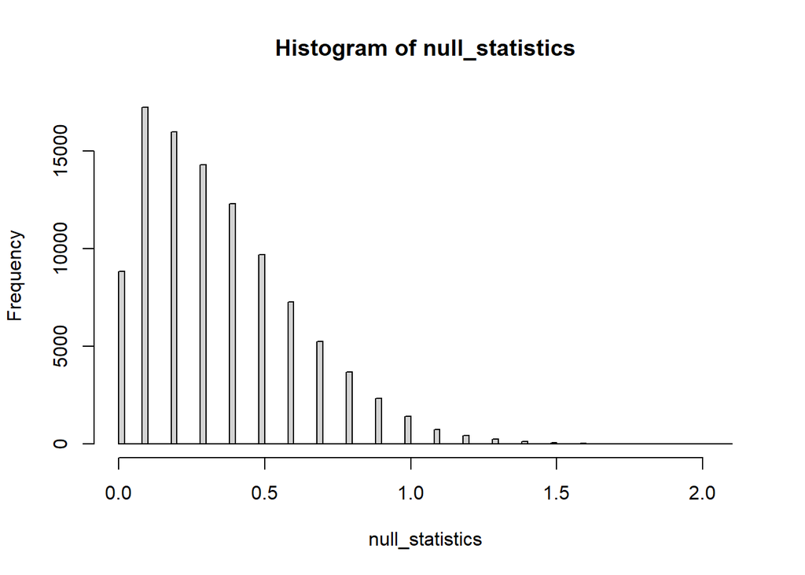

```r
null_statistics = replicate(1e5, {
  X = rpois(N, lambda=lambda0)
  abs(mean(X) - lambda0)
})
hist(null_statistics, 100)
```

```r
critical_value = quantile(null_statistics, 0.95)
critical_value
```

```
## 95%
## 0.9
```

Since the observed test statistic does not exceed the critical value, we do not reject $H_0$.

$~$

#### 9.3.0.8 Exercise

Let $X = (0, 3, 3, 4, 2, 0, 1, 4, 0, 4)$ be observations from a Poisson distribution with parameter $\lambda$. Calculate the two-sided Wald test statistic for $H_0:\lambda = 2$ against $A: \lambda \neq 2$ **numerically** and find its critical value numerically. Do we reject $H_0$?

**Click for the answer**

```r
X = c(0, 3, 3, 4, 2, 0, 1, 4, 0, 4)
N = length(X)
lambda0 = 2
loglik_fun = function(lambda) sum(dpois(X, lambda=lambda, log=TRUE))

MLE = optimize(loglik_fun, c(0,4), maximum=TRUE)$maximum
observed_statistic = (MLE - lambda0)^2 #squared because two-sided
observed_statistic
```

```
## [1] 0.00999994
```

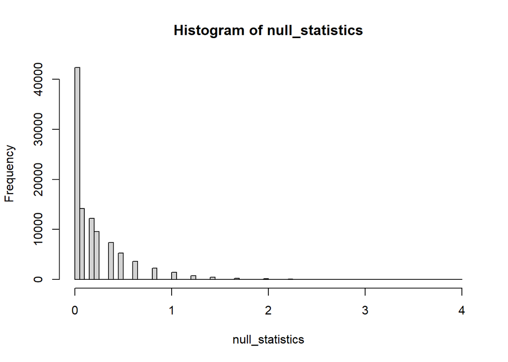

```r
null_statistics = replicate(1e5, {
  X = rpois(N, lambda=lambda0)
  loglik_fun = function(lambda) sum(dpois(X, lambda=lambda, log=TRUE))
  MLE = optimize(loglik_fun, c(0,4), maximum=TRUE)$maximum
  (MLE - lambda0)^2
})
hist(null_statistics, 100)
```

```r
critical_value = quantile(null_statistics, 0.95)
critical_value
```

```
##      95%
## 0.809984
```

Since the observed test statistic does not exceed the critical value, we do not reject $H_0$.

Alternatively, we could have used the not-squared version

```r
observed_statistic = MLE - lambda0
observed_statistic
```

```
## [1] 0.0999997
```

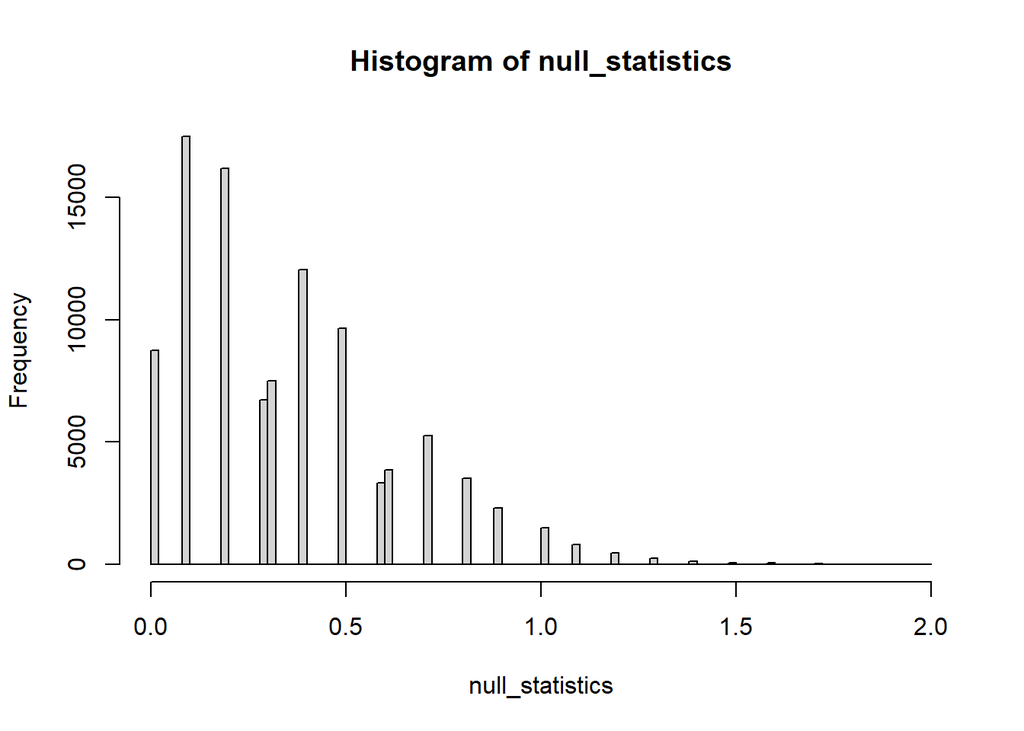

```r
null_statistics = replicate(1e5, {
  X = rpois(N, lambda=lambda0)
  loglik_fun = function(lambda) sum(dpois(X, lambda=lambda, log=TRUE))
  MLE = optimize(loglik_fun, c(0,4), maximum=TRUE)$maximum
  abs(MLE - lambda0)
})
hist(null_statistics, 100)
```

```r
critical_value = quantile(null_statistics, 0.975)
critical_value
```

```
##    97.5%
## 1.000003
```

But then we should check whether the test statistic is greater than the critical value or smaller than minus the critical value.

$~$

#### 9.3.0.9 Exercise

Suppose we have observed $X=(-1.2, 1.8, -0.5, 0.4, 3.4, 3.6)$ from a normal model with with known $\mu=1$ and unknown $\sigma^2$. Test $H_0:\sigma^2=1$ against $A:\sigma^2 \neq 1$ numerically using a likelihood ratio test.

**Click for the answer**

```r
X = c(-1.2,  1.8, -0.5,  0.4,  3.4,  3.6)
N = length(X)
loglik_fun = function(sig2) sum(dnorm(X, mean=1, sd=sqrt(sig2), log=TRUE))
hat_sig2 = optimize(loglik_fun, c(0, 10), maximum=TRUE)$maximum
sig2_0 = 1
observed_statistic = loglik_fun(hat_sig2) - loglik_fun(sig2_0)
null_statistics = replicate(1e5, {
  X <- rnorm(N, mean=1, sd=sqrt(sig2_0))
  loglik_fun = function(sig2) sum(dnorm(X, mean=1, sd=sqrt(sig2), log=TRUE))
  hat_sig2 = optimize(loglik_fun, c(0, 10), maximum=TRUE)$maximum
  loglik_fun(hat_sig2) - loglik_fun(sig2_0)
})
critical_value = quantile(null_statistics, 0.95)
observed_statistic
```

```
## [1] 3.602949
```

```r
critical_value
```

```
##      95%
## 2.023098
```

Since the observed statistic is greater than its critical value, we reject $H_0$.

$~$

## 9.4 What have we learned

- We can calculate Wald, score and likelihood ratio test statistics both numerically and analytically
- We can find critical values for these test statistic (and any others) by simulation
- We can say whether or not two test statistics are equivalent

# 10 Asymptotic tests and confidence intervals

We saw that in the exponential distribution model the one-sided score and Wald tests are equivalent. It is often the case that they are similar to each other, and that their two-sided variants are similar tot the likelihood ratio test. We will now investigate the behavior of the three tests in large samples.

## 10.1 Large sample distributions

We will use the fact that, as $N$ increases, well-behaved likelihoods start to look more and more like linkelihoods of $\mu$ in a normal distribution. Let us investigate the Wald, Likelihood Ratio and Score tests for the case of testing $H_0: \mu=0$ against $A: \mu \neq 0$ with $\sigma^2$ known. In the normal distribution likelihood, the Fisher information does not depend on $\mu$, we we denote it simply by $\mathcal{I}$. Remember that $\mathcal{I} = n/\sigma^2$.

The Wald test is easy to calculate. It has test statistic

$$T_\mathrm{Wald}= \hat\mu-0=\hat\mu.$$

$~$

#### 10.1.0.1 Exercise

Show that the Wald test statistic has a normal distribution with mean 0 and variance $1/\mathcal{I}$.

**Click for the answer**

$\hat\mu = n^{-1} \sum_{i=1}^n x_i$ has mean 0 and variance $\sigma^2/n$. The Fisher Information of $\mu$ in the normal likelihood is $n/\sigma^2$.

$~$

#### 10.1.0.2 Exercise

Show that the Likelihood Ratio Test statistic for $H_0: \mu=0$ is $T_\mathrm{LRT}= \frac{n}{2\sigma^2} \hat\mu^2$ and that the distribution of $2T_\mathrm{LRT}$ is $\chi^2_1$.

**Click for the answer**

We use the parabola formula we derived for the log likelihood of the normal distribution in Lecture 6.

$$T_\mathrm{LRT} = \mathrm{loglik}(\hat\mu) - \mathrm{loglik}(0) \\
= \Big(-\frac{n}{2\sigma^2} \hat\mu^2 + \frac{\sum_{i=1}^n x_i}{\sigma^2}\hat\mu - \frac{\sum_{i=1}^n x_i^2}{2\sigma^2} - \frac n2 \log(2\pi\sigma^2)\Big)
-\Big(-\frac{n}{2\sigma^2}\cdot 0^2 + \frac{\sum_{i=1}^n x_i}{\sigma^2}\cdot 0 - \frac{\sum_{i=1}^n x_i^2}{2\sigma^2} - \frac n2 \log(2\pi\sigma^2)\Big) \\
= -\frac{n}{2\sigma^2} \hat\mu^2 + \frac{\sum_{i=1}^n x_i}{\sigma^2}\hat\mu \\
= -\frac{n}{2\sigma^2} \hat\mu^2 + \frac{n\hat\mu}{\sigma^2}\hat\mu \\
= \frac{n}{2\sigma^2} \hat\mu^2$$

Since $\hat\mu$ is normally distributed with mean 0 and variance $\sigma^2/n$, $\sqrt{\frac{n}{\sigma^2}} \hat\mu$ has a standard normal distribution. It follows that
$$2 T_\mathrm{LRT} = 2\frac{n}{2\sigma^2} \hat\mu^2 = \Big( \sqrt{\frac{n}{\sigma^2}} \hat\mu \Big)^2$$
is distributed like the square of a standard normal variable, which is a chi-square with 1 degree of freedom.

$~$

$~$

#### 10.1.0.3 Exercise

Show that the Score Test statistic for $H_0: \mu=0$ is $T_\mathrm{score} = \frac{n}{\sigma^2} \hat\mu$, and that $T_\mathrm{score}$ has a normal distribution with mean 0 and variance $\mathcal{I}$.

**Click for the answer**

In Lecture 6 we found that the score for the likelihood of the normal distribution is
$$\mathrm{loglik}'(\mu) = -\frac{n}{\sigma^2} \mu + \frac{\sum_{i=1}^n x_i}{\sigma^2}$$
. We calculate

$$T_\mathrm{score} = \mathrm{loglik}'(0) = -\frac{n}{\sigma^2} \cdot 0 + \frac{\sum_{i=1}^n x_i}{\sigma^2} \\
= \frac{n\hat\mu}{\sigma^2}$$

Since $\hat\mu$ is normally distributed with mean 0 and variance $\sigma^2/n$, we have that $T_\mathrm{score}$ is normally distributed with mean 0 and
$$\mathrm{Var}(T_\mathrm{score}) = \Big(\frac{n}{\sigma^2}\Big)^2\mathrm{Var}(\hat\mu) = \Big(\frac{n}{\sigma^2}\Big)^2\frac{\sigma^2}{n} = \frac{n}{\sigma^2}.$$

$~$

The results that hold for the normal distribution likelihood hold for large samples in any well-behaved likelihood. We have the following *asymptotic distributions* for the three classical tests. In large samples, under $H_0$,

> - The Wald test statistic is normally distributed with mean 0 and variance $1/\mathcal{I}$.
> - Two times the likelihood ratio test is chi-squared distributed with 1 degree of freedom.
> - The score test statistic is normally distributed with mean 0 and variance $\mathcal{I}$.

If we are not in the normal distribution case, generally $\mathcal{I}$ depends on the parameter $\theta$, which is known under $H_0:\theta=\theta_0$. Since under $H_0$ if $N$ is large $\hat\theta \approx \theta_0$, we may either use $\mathcal{I}(\theta_0)$ or $\mathcal{I}(\hat\theta)$. It is conventional to use $\mathcal{I}(\theta_0)$ for the score test and $\mathcal{I}(\hat\theta)$ for the Wald test.

The asymptotic distributions give us an easier way to calculate critical values of the three test statistics. We reject, e.g. using the Wald test one-sided if
$$T_\mathrm{Wald} > z_{1-\alpha}/ \sqrt{\mathcal{I}(\hat\theta)},$$
where $z_{1-\alpha}$ is the $1-\alpha$-quantile of the standard normal distribution.

$~$

#### 10.1.0.4 Exercise

Let $X = (0, 3, 3, 4, 2, 0, 1, 4, 0, 4)$ be observations from a Poisson distribution with parameter $\lambda$. Calculate the two-sided Wald test statistic for $H_0:\lambda = 2$ against $A: \lambda \neq 2$ **analytically** and find its critical value **asymptotically**. Do we reject $H_0$?

**Click for the answer**

We already calculated the MLE as $\hat\lambda = \bar X$.

To use the asymptotic distribution we must calculate the Fisher Information. It is not specified in the question whether we should do that analytically or numerically, so let’s try both ways.

Analytically, we found that
$$\mathrm{loglik}'(\lambda) = -n + \lambda^{-1} \sum_{i=1}^n x_i,$$
so
$$\mathrm{loglik}''(\lambda) = - \lambda^{-2} \sum_{i=1}^n x_i.$$
The Fisher Information is
$$\mathrm{E}[-\mathrm{loglik}''(\lambda)] = \mathrm{E}[\lambda^{-2} \sum_{i=1}^n x_i] \\ = \lambda^{-2}n\lambda \\ = n/\lambda.$$
In the MLE, this is $n/\hat\lambda = n/\bar X$.

Numerically, we have

```r
X = c(0, 3, 3, 4, 2, 0, 1, 4, 0, 4)
N = length(X)
lambda0 = 2
hatlambda = mean(X)
loglik_fun = function(lambda) sum(dpois(X, lambda=lambda, log=TRUE))

step = 0.001
lambda_grid = hatlambda + c(-step, 0, step)
loglik <- sapply(lambda_grid, loglik_fun)
score = diff(loglik)/step
FisherInfo_numeric = -diff(score)/step
FisherInfo_numeric
```

```
## [1] 4.761905
```

```r
FisherInfo = N/hatlambda
FisherInfo
```

```
## [1] 4.761905
```

```r
observed_statistic = hatlambda - lambda0
observed_statistic
```

```
## [1] 0.1
```

```r
critical_value = qnorm(0.975) / sqrt(FisherInfo)
critical_value
```

```
## [1] 0.8981683
```

Since the observed test statistic does not exceed the critical value and is not less than minus the critical value, we do not reject $H_0$.

In this case we see an excellent correspondence between the asymptotic results and the numerical ones. This is not always the case with such small $N$.

$~$

A well-known example of a Wald test is the Binomial Test. Assuming a binomial distribution with known $n$ and unknown $p$, for testing $H_0: p=p_0$ it uses $\hat p - p_0$ as a test statistic, where $\hat p = X/N$ is the MLE, and compares it to the asymptotic normal null distribution with variance equal to $1/\cal I(\hat p) = \hat p (1-\hat p)/N$.

$~$

#### 10.1.0.5 Exercise

Verify that the binomial test is the asymptotic Wald test for this model.

**Click for the answer**

To verify that the binomial test is the asymptotic Wald test, we only need to check that $\hat p$ is indeed the MLE and that $1/\mathcal I(\hat p) = \hat p (1-\hat p)/n$. Brace yourself for a long calculation.

The density is
$$f(x) = {x \choose N} p^x(1-p)^{(N-x)}.$$
The log density is
$$log f(x) = \log {x \choose N} + \log(p) x + \log(1-p) (N-x),$$
so this is also the log likelihood
$$\textrm{loglik}(p) = \log {x \choose N} + \log(p) x + \log(1-p) (N-x).$$
Differentiating with respect to $p$, the first term drops out and we get the score
$$\textrm{loglik}'(p) = X/p - (N-X)/(1-p).$$
Solving, we get
$$X/p - (N-X)/(1-p) = 0 \\ X/p = (N-X)/(1-p) \\ X(1-p) = p(N-X) \\ X-Xp = pN-Xp \\ X = pN \\ p = X/N,$$
so $\hat p = X/N$ is indeed the MLE.

For the Fisher Information, we differentiate again to get
$$\textrm{loglik}''(p) = -X/p^2 - (N-X)/(1-p)^2.$$
The Fisher information is therefore
$$\mathcal{I}(p) = \mathrm{E}[-\textrm{loglik}''(p)] \\= \mathrm{E}[X/p^2 + (N-X)/(1-p)^2] \\= Np/p^2 + N(1-p)/(1-p)^2 \\= N/p + N/(1-p) \\= \frac{N(1-p)}{p(1-p)} + \frac{Np}{p(1-p)} \\= \frac{N}{p(1-p)}.$$

Indeed $\mathcal I(\hat p) = \frac{N}{\hat p(1-\hat p)}$.

$~$

#### 10.1.0.6 Exercise

Suppose we have observed $X=(-1.2, 1.8, -0.5, 0.4, 3.4, 3.6)$ from a normal model with with known $\mu=0$ and unknown $\sigma^2$. Test $H_0:\sigma^2=1$ against $A:\sigma^2 \neq 1$ with a likelihood ratio test. Calculate the test statistic numerically but use the asymptotic critical value.

**Click for the answer**

```r
X = c(-1.2,  1.8, -0.5,  0.4,  3.4,  3.6)
N = length(X)
loglik_fun = function(sig2) sum(dnorm(X, mean=0, sd=sqrt(sig2), log=TRUE))
hat_sig2 = optimize(loglik_fun, c(0, 10), maximum=TRUE)$maximum
sig2_0 = 1
observed_statistic = loglik_fun(hat_sig2) - loglik_fun(sig2_0)
critical_value = qchisq(0.95, df=1)/2
observed_statistic
```

```
## [1] 7.015942
```

```r
critical_value
```

```
## [1] 1.920729
```

Since the observed statistic is greater than its critical value, we reject $H_0$.

$~$

#### 10.1.0.7 Exercise

Suppose we have observed $X=(-1.2, 1.8, -0.5, 0.4, 3.4, 3.6)$ from a normal model with with known $\mu=0$ and unknown $\sigma^2$. Test $H_0:\sigma^2=1$ against $A:\sigma^2 > 1$ with a one-sided score test. Calculate the test statistic analytically and use the asymptotic critical value.

**Click for the answer**

The normal density with $\mu=0$ is
$$f(x) = \frac1{\sqrt{2\pi\sigma^2}} e^{-\frac{x^2}{2\sigma^2}},$$
so
$$\log f(x) = -\frac12 \log(2\pi\sigma^2) - \frac{x^2}{2\sigma^2}.$$
The log likelihood is therefore
$$\mathrm{loglik}(\sigma^2) = \sum_{i=1}^n \log f(x_i) \\= -\frac n2 \log(2\pi\sigma^2) - \frac{1}{2\sigma^2}\sum_{i=1}^n x_i^2.$$
The score is
$$\mathrm{loglik}'(\sigma^2) = - \frac n{2\sigma^2} + \frac{1}{2\sigma^4}\sum_{i=1}^n x_i^2.$$
We find

$$T_\mathrm{score} = \mathrm{loglik}'(1) = - \frac n{2} + \frac{1}{2}\sum_{i=1}^n x_i^2.$$
The second derivative of the likelihood is
$$\mathrm{loglik}''(\sigma^2) = \frac n{2\sigma^4} - \frac{1}{\sigma^6}\sum_{i=1}^n x_i^2,$$
so the Fisher Information is
$$\mathcal{I}(\sigma^2) = \mathrm{E}[-\mathrm{loglik}''(\sigma^2)] =\\ -\frac n{2\sigma^4} + \frac{1}{\sigma^6}\mathrm{E}[\sum_{i=1}^n x_i^2] \\= -\frac n{2\sigma^4} + \frac{n\sigma^2}{\sigma^6} \\= \frac n{2\sigma^4}.$$
The variance of the score is $\mathcal{I}(1) = n/2.$

```r
X=c(-1.2,  1.8, -0.5,  0.4,  3.4,  3.6)
N <- length(X)
score_statistic <- -N/2 + sum(X^2)/2
critical_value <- qnorm(0.95, mean=0, sd=sqrt(N/2))
score_statistic
```

```
## [1] 11.805
```

```r
critical_value
```

```
## [1] 2.84897
```

Since the test statistic exceeds the critical value, we reject $H_0$.

$~$

#### 10.1.0.8 Exercise

Suppose we have observed $X=(-1.2, 1.8, -0.5, 0.4, 3.4, 3.6)$ from a normal model with with known $\mu=0$ and unknown $\sigma^2$. Test $H_0:\sigma^2=1$ against $A:\sigma^2 > 1$ with a one-sided score test. Calculate the test statistic numerically and use a numerically calculated critical value.

**Click for the answer**

```r
X=c(-1.2,  1.8, -0.5,  0.4,  3.4,  3.6)
N = length(X)
loglik_fun = function(sig2) sum(dnorm(X, mean=0, sd=sqrt(sig2), log=TRUE))
sig2_0 = 1
step=0.001
sig2_grid <- sig2_0 + c(-step/2, step/2)
observed_statistic <- diff(sapply(sig2_grid, loglik_fun))/step
null_statistics = replicate(1e5, {
  X <- rnorm(N, mean=0, sd=sqrt(sig2_0))
  loglik_fun = function(sig2) sum(dnorm(X, mean=0, sd=sqrt(sig2), log=TRUE))
  diff(sapply(sig2_grid, loglik_fun))/step
})
critical_value = quantile(null_statistics, 0.95)
observed_statistic
```

```
## [1] 11.805
```

```r
critical_value
```

```
##      95%
## 3.287895
```

Since the test statistic exceeds the critical value, we reject $H_0$.

$~$

Finally, a note about the similarity of the three tests.

$~$

#### 10.1.0.9 Exercise

Show that in the normal model likelihood $T_\mathrm{Wald}$ and $T_\mathrm{score}$ are equivalent, and that $T_\mathrm{Wald}^2$, $T_\mathrm{score}^2$ and $T_\mathrm{LRT}$ are equivalent.

**Click for the answer**

$~$

Again, what holds for the normal distribution, holds for every well-behaved model if $N$ is large. This principle also applies to the equivalence of the Wald, Likelihood ratio and score tests: As $N$ grows, if the likelihood is well-behaved, the difference between the results of two-sided Wald, likelihood ratio and two-sided score tests vanishes. We say

> The two-sided Wald, likelihood ratio and two-sided score tests are *asymptotically equivalent*.

An overview of the Wald, score and likelihood ratio tests and their asymptotic distributions:

| Statistic | Definition | Distribution |
| --- | --- | --- |
| Wald | $\hat\theta - \theta_0$ | $\mathcal{N}\{0, 1/\cal I(\hat\theta)\}$ |
| Score | $\textrm{loglikelihood}'(\theta_0)$ | $\mathcal{N}\{0, \cal I(\theta_0)\}$ |
| Likelihood ratio | $\textrm{loglikelihood}(\hat\theta) - \textrm{loglikelihood}(\theta_0)$ | $\frac12 \chi^2_{\mathrm{df}=1}$ |

## 10.2 Confidence intervals from Wald, likelihood ratio (and score) tests

We have discussed how the likelihood suggests useful test statistics: the Wald, likelihood ratio and score tests. We have also seen that hypothesis tests can be inverted to get confidence intervals. What do the confidence intervals of the Wald, likelihood ratio and score tests look like? This is what we will look at in the first half of this lecture.

In Lecture 8 we have learned that we can construct a confidence interval by inverting a hypothesis test. This means that we can find weird confidence intervals with weird hypothesis tests.

$~$

#### 10.2.0.1 Exercise

Suppose we have observed $X = (1.0, 5.2, 2.1, 9.3, 0.7, 1.5, 2.5, 0.9, 1.0, 3.8, 6.6, 1.6)$ from an exponential distribution. Suppose we test $H_0: \lambda=\lambda_0$ with a one-sided test that rejects for large values of $\hat\lambda$ only. Use the asymptotic distribution to find the critical value. What does the resulting confidence interval look like? What is unusual about this interval?

**Click for the answer**

```r
X = c(1.0, 5.2, 2.1, 9.3, 0.7, 1.5, 2.5, 0.9, 1.0, 3.8, 6.6, 1.6)
N = length(X)
hat_lambda = 1/mean(X)
lower_bound = hat_lambda - hat_lambda * qnorm(0.95) / sqrt(N)
upper_bound = Inf
c(lower_bound, upper_bound)
```

```
## [1] 0.1740901       Inf
```

This is a perfectly valid confidence interval, but it looks strange because it is one-sided. Perfectly valid in theory, one-sided intervals are seldom used in practice.

This interval has an extremely weak upper bound that includes all values of $\lambda$ higher than $\hat\lambda$. In compensation, it has a slightly sharper lower bound than the two-sided interval, using $z_{1-\alpha}$ instead of $z_{1-\alpha/2}$.

$~$

In Lecture 9 we have learned about Wald, likelihood ratio and score tests as good ways to construct hypothesis tests. What do the confidence intervals we construct from these tests look like?

We focus on the asymptotic distributions of these tests because they are easier to work with. Remember that for large samples, under $H_0$,

> - The Wald test statistic is normally distributed with mean 0 and variance $1/\mathcal{I}$.
> - Two times the likelihood ratio test is chi-squared distributed with 1 degree of freedom.
> - The score test statistic is normally distributed with mean 0 and variance $\mathcal{I}$.

Inverting the score test often involves quite a bit of algebra even for relatively simple distributions, as we see in the next exercise. We will focus here on the Wald and likelihood ratio test based confidence intervals.

$~$

#### 10.2.0.2 Exercise

Suppose we have observed $X = (1.0, 5.2, 2.1, 9.3, 0.7, 1.5, 2.5, 0.9, 1.0, 3.8, 6.6, 1.6)$ from an exponential distribution with unknown $\lambda$. Formulate $H_0: \lambda = \lambda_0$. Use a grid of values of $\lambda_0$ to find where the two-sided score test does *not* reject. Use the asymptotic distribution of the score test statistic. Use that the score of the exponential distribution is $n/\lambda - n\bar X$ and the Fisher information is $n/\lambda^2$. What is the resulting confidence interval for $\lambda$?

**Click for the answer**

```r
X = c(1.0, 5.2, 2.1, 9.3, 0.7, 1.5, 2.5, 0.9, 1.0, 3.8, 6.6, 1.6)
N <- length(X)
lambda0 <- seq(0.001,1, by=0.001)
score <- N/lambda0 - N* mean(X)
FisherInfo <- N/lambda0^2
critical_value <- qnorm(0.975) * sqrt(FisherInfo)
reject <- abs(score) > critical_value
c(min(lambda0[!reject]), max(lambda0[!reject]))
```

```
## [1] 0.144 0.519
```

$~$

#### 10.2.0.3 Exercise

Suppose we have observed $X = (1.0, 5.2, 2.1, 9.3, 0.7, 1.5, 2.5, 0.9, 1.0, 3.8, 6.6, 1.6)$ from an exponential distribution with unknown $\lambda$. Formulate $H_0: \lambda = \lambda_0$. Find analytically for which values of $\lambda_0$ the two-sided score test does *not* reject. Use the asymptotic distribution of the score test statistic. What is the resulting confidence interval for $\lambda$?

**Click for the answer**

The score test statistic we have calculated before as
$$T_\mathrm{score} = n/\lambda_0 - n\bar X.$$
The Fisher information in $\lambda_0$ is $\mathcal{I}(\lambda_0) = n/\lambda_0^2$. We can use the asymptotic approximation (although maybe we shouldn’t because $n$ is quite small) that says that, under $H_0$, $T_\mathrm{score}$ is approximately normal with mean 0 and variance $\mathcal{I}(\lambda_0)$. The two-sided test rejects when either
$$T_\mathrm{score} > z_{1-\alpha/2} \sqrt{\mathcal{I}(\lambda_0)} \qquad \textrm{or} \qquad T_\mathrm{score} < -z_{1-\alpha/2} \sqrt{\mathcal{I}(\lambda_0)}.$$
It follows that it does not reject when
$$T_\mathrm{score} \leq z_{1-\alpha/2} \sqrt{\mathcal{I}(\lambda_0)} \qquad \textrm{and} \qquad T_\mathrm{score} \geq -z_{1-\alpha/2} \sqrt{\mathcal{I}(\lambda_0)}.$$

Working out the left-hand side, we get
$$T_\mathrm{score} \leq z_{1-\alpha/2} \sqrt{\mathcal{I}(\lambda_0)} \\
n/\lambda_0 - n\bar X \leq z_{1-\alpha/2} \sqrt{n}/\lambda_0 \\
\frac{n-z_{1-\alpha/2} \sqrt{n}}{\lambda_0} \leq n\bar X \\
\frac{n-z_{1-\alpha/2} \sqrt{n}}{n \bar X} \leq \lambda_0 \\
\frac{1-z_{1-\alpha/2}/\sqrt{n}}{\bar X} \leq \lambda_0.$$

The right-hand side similarly gives
$$\frac{1+z_{1-\alpha/2}/\sqrt{n}}{\bar X} \geq \lambda_0.$$

The score-based confidence interval is therefore from
$$\frac{1-z_{1-\alpha/2}/\sqrt{n}}{\bar X} \qquad \textrm{to} \qquad \frac{1+z_{1-\alpha/2}/\sqrt{n}}{\bar X}$$
We calculate

```r
X = c(1.0, 5.2, 2.1, 9.3, 0.7, 1.5, 2.5, 0.9, 1.0, 3.8, 6.6, 1.6)
N = length(X)
lower_bound = (1 - qnorm(0.975)/sqrt(N))/mean(X)
upper_bound = (1 + qnorm(0.975)/sqrt(N))/mean(X)
c(lower_bound, upper_bound)
```

```
## [1] 0.1439361 0.5190474
```

$~$

#### 10.2.0.4 Exercise

Suppose we have observed $X = (1.0, 5.2, 2.1, 9.3, 0.7, 1.5, 2.5, 0.9, 1.0, 3.8, 6.6, 1.6)$ from an exponential distribution with unknown $\lambda$. Formulate $H_0: \lambda = \lambda_0$. For which values of $\lambda_0$ does the two-sided Wald test *not* reject? Use the asymptotic distribution of the Wald test statistic. What is the resulting confidence interval for $\lambda$?

**Click for the answer**

The Wald test statistic we have calculated before as
$$T_\mathrm{Wald} = 1/\bar X- \lambda_0.$$
The Fisher information in $\hat\lambda$ is $\mathcal{I}(\hat\lambda) = n/\hat\lambda^2 = n\bar X^2$. We can use the asymptotic approximation (although maybe we shouldn’t because $n$ is quite small) that says that, under $H_0$, $T_\mathrm{Wald}$ is approximately normal with mean 0 and variance $1/\mathcal{I}(\hat\lambda)$. The two-sided test rejects when either
$$T_\mathrm{Wald} > z_{1-\alpha/2} \sqrt{1/\mathcal{I}(\hat\lambda)} \qquad \textrm{or} \qquad T_\mathrm{Wald} < -z_{1-\alpha/2} \sqrt{1/\mathcal{I}(\hat\lambda)}.$$
It follows that it does not reject when
$$T_\mathrm{Wald} \leq z_{1-\alpha/2} \sqrt{1/\mathcal{I}(\hat\lambda)} \qquad \textrm{and} \qquad T_\mathrm{Wald} \geq -z_{1-\alpha/2} \sqrt{1/\mathcal{I}(\hat\lambda)}.$$

Working out the left-hand side, we get
$$T_\mathrm{Wald} \leq z_{1-\alpha/2} \sqrt{1/\mathcal{I}(\hat\lambda)} \\
1/\bar X - \lambda_0 \leq z_{1-\alpha/2}/(\bar X\sqrt{n})\\
1/\bar X - z_{1-\alpha/2} /(\bar X\sqrt{n}) \leq \lambda_0.$$

The right-hand side similarly gives
$$1/\bar X + z_{1-\alpha/2}/ (\bar X \sqrt{n})\geq \lambda_0.$$

The Wald-based confidence interval is therefore from
$$1/\bar X-z_{1-\alpha/2}/(\bar X \sqrt{n}) \qquad \textrm{to} \qquad 1/\bar X+z_{1-\alpha/2}/(\bar X \sqrt{n})$$
We calculate

```r
X = c(1.0, 5.2, 2.1, 9.3, 0.7, 1.5, 2.5, 0.9, 1.0, 3.8, 6.6, 1.6)
N = length(X)
lower_bound = 1/mean(X) - qnorm(0.975)/(sqrt(N)*mean(X))
upper_bound = 1/mean(X) + qnorm(0.975)/(sqrt(N)*mean(X))
c(lower_bound, upper_bound)
```

```
## [1] 0.1439361 0.5190474
```

$~$

#### 10.2.0.5 Exercise

Note that the Wald and score confidence intervals we have calculated are exactly the same. Why is that?

**Click for the answer**

In one of the exercises of Day 9 we found that for the exponential likelihood the Wald and score tests are equivalent. If tests are equivalent, they either both reject or both don’t reject. The values of $\lambda_0$ for which they don’t reject are therefore the same, so the confidence intervals are the same.

$~$

## 10.3 Wald confidence intervals

Wald confidence intervals always have a simple form. The Wald test of $H_0:\theta=\theta_0$, using its aymptotic distribution, does not reject when
$$T_\mathrm{Wald} = \hat\theta-\theta_0\leq z_{1-\alpha/2} \sqrt{1/\mathcal{I}(\hat\theta)} \qquad \textrm{and} \qquad T_\mathrm{Wald} = \hat\theta-\theta_0 \geq -z_{1-\alpha/2} \sqrt{1/\mathcal{I}(\hat\theta)}.$$
This is the same as not rejecting when
$$\theta_0\geq \hat\theta - z_{1-\alpha/2} \sqrt{1/\mathcal{I}(\hat\theta)} \qquad \textrm{and} \qquad \theta_0 \leq \hat\theta + z_{1-\alpha/2} \sqrt{1/\mathcal{I}(\hat\theta)}.$$

> The asymptotic Wald confidence interval is from $\hat\theta - z_{1-\alpha/2}\sqrt{1/\mathcal{I}(\hat\theta)}$ to $\hat\theta + z_{1-\alpha/2}\sqrt{1/\mathcal{I}(\hat\theta)}$.

$~$

#### 10.3.0.1 Exercise

Find the asymptotic Wald confidence interval for a $\lambda$ in a Poisson-distribution.

**Click for the answer**

We have previously calculated that the Poisson MLE is $\hat\lambda = \bar X$, and the Poissin Fisher Information is $\mathcal{I}(\lambda) = n/\lambda$. It follows that the Poisson confidence interval for $\lambda$ goes from
$$\hat\lambda - z_{1-\alpha/2} \sqrt(\hat\lambda/n) = \bar X - z_{1-\alpha/2} \sqrt{\bar X/n}$$
to $\bar X + z_{1-\alpha/2} \sqrt{\bar X/n}$.

$~$

#### 10.3.0.2 Exercise

Calculate the coverage for the Wald confidence interval of the exponential distribution if the true $\lambda=1/4$ and $N=6$.

**Click for the answer**

```r
N = 6
lambda = 1/4
cover = replicate(1e5, {
  X = rexp(N, rate=lambda)
  lower_bound = 1/mean(X) - qnorm(0.975)/(sqrt(N)*mean(X))
  upper_bound = 1/mean(X) + qnorm(0.975)/(sqrt(N)*mean(X))
  (lower_bound <= lambda) & (upper_bound >= lambda)
})
mean(cover)
```

```
## [1] 0.95671
```

$~$

## 10.4 Likelihood confidence intervals

The confidence interval of the likelihood ratio test also has a relatively simple form. We fail to reject when
$$T_\mathrm{LRT} = 2(\mathrm{loglik}(\hat\theta) - \mathrm{loglik}(\theta_0)) \leq \chi_{1-\alpha},$$
which is when
$$\mathrm{loglik}(\theta_0) \geq \mathrm{loglik}(\hat\theta) -\chi_{1-\alpha}/2.$$

Since $\chi_{1-\alpha}/2 \approx 1.92$, the likelihood ratio confidence interval for $\theta$ consists of exactly those $\theta$ for which the log likelihood ratio with the MLE is less than 1.92. Let’s visualize that:

```r
critical_value = qchisq(0.95,df=1)/2
critical_value
```

```
## [1] 1.920729
```

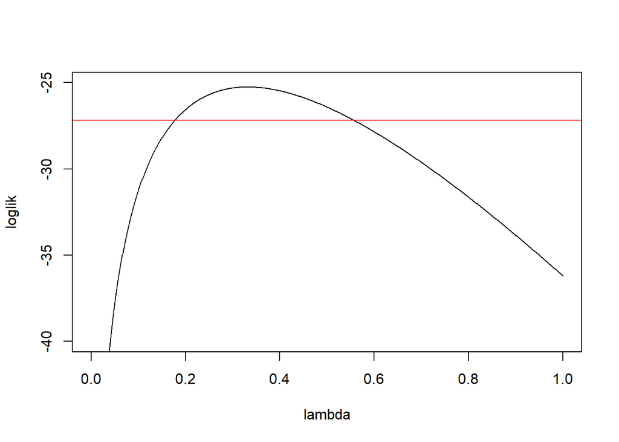

```r
X = c(1.0, 5.2, 2.1, 9.3, 0.7, 1.5, 2.5, 0.9, 1.0, 3.8, 6.6, 1.6)
loglik_fun = function(lambda) sum(dexp(X, rate=lambda, log=TRUE))
lambda = seq(0, 1, by=0.001)
loglik = sapply(lambda, loglik_fun)
plot(lambda, loglik, type='l', ylim=c(-40,-25))
hat_lambda = optimize(loglik_fun, c(0,6), maximum = TRUE)$maximum
abline(h=loglik_fun(hat_lambda)-critical_value, col='red')
```

We may find the boundaries of the confidence interval with uniroot.

```r
f0 <- function(lambda) loglik_fun(lambda) - loglik_fun(hat_lambda) + critical_value
lower_bound = uniroot(f0, c(0.001, hat_lambda))$root
upper_bound = uniroot(f0, c(hat_lambda, 1))$root
c(lower_bound, upper_bound)
```

```
## [1] 0.1775346 0.5559667
```

> The likelihood confidence interval consist of all values of $\theta$ for which the log likelihood is no more than 1.92 below the log likelihood of the MLE.

#### 10.4.0.1 Exercise

Let $X = (0, 3, 3, 4, 2, 0, 1, 4, 0, 4)$ be observations from a Poisson distribution with parameter $\lambda$. Find the likelihood confidence interval for $\lambda$.

**Click for the answer**

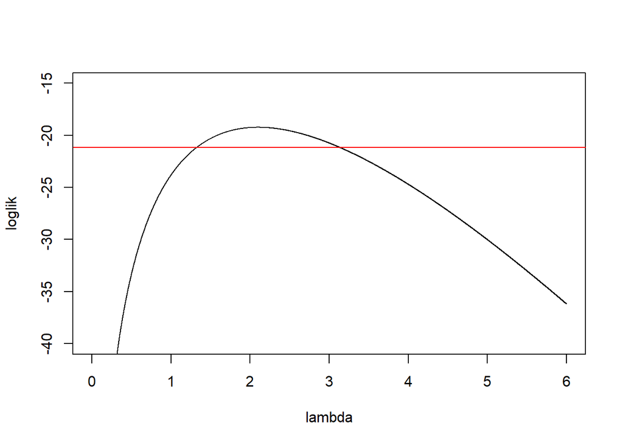

```r
critical_value = qchisq(0.95,df=1)/2
X = c(0, 3, 3, 4, 2, 0, 1, 4, 0, 4)
loglik_fun = function(lambda) sum(dpois(X, lambda=lambda, log=TRUE))
lambda = seq(0, 6, by=0.001)
loglik = sapply(lambda, loglik_fun)
plot(lambda, loglik, type='l', ylim=c(-40,-15))
hat_lambda = optimize(loglik_fun, c(0,6), maximum = TRUE)$maximum
abline(h=loglik_fun(hat_lambda)-critical_value, col='red')
```

```r
f0 <- function(lambda) loglik_fun(lambda) - loglik_fun(hat_lambda) + critical_value
lower_bound = uniroot(f0, c(0.001, hat_lambda))$root
upper_bound = uniroot(f0, c(hat_lambda, 6))$root
c(lower_bound, upper_bound)
```

```
## [1] 1.325072 3.130524
```

$~$

#### 10.4.0.2 Exercise

Calculate the coverage for the likelihood confidence interval of the exponential distribution if the true $\lambda=1/4$ and $N=6$. Hint: use wide intervals in uniroot.

**Click for the answer**

```r
N = 6
lambda = 1/4
critical_value = qchisq(0.95,df=1)/2
cover = replicate(1e4, {
  X = rexp(N, rate=lambda)
  loglik_fun = function(lambda) sum(dexp(X, rate=lambda, log=TRUE))
  loglik = sapply(lambda, loglik_fun)
  hat_lambda = optimize(loglik_fun, c(0,1), maximum = TRUE)$maximum
  f0 <- function(lambda) loglik_fun(lambda) - loglik_fun(hat_lambda) + critical_value
  lower_bound = uniroot(f0, c(0.001, hat_lambda))$root
  upper_bound = uniroot(f0, c(hat_lambda, 10))$root
  (lower_bound <= lambda) & (upper_bound >= lambda)
})
mean(cover)
```

```
## [1] 0.9506
```

$~$

## 10.5 What have we learned

- We can use the asymptotic distribution of the Wald, score and likelihood ratio test statistics to find asymptotic critical values.
- We know that the Wald, score and likelihood ratio test statistics are asymptotically equivalent.
- We can calculate asymptotic Wald and likelihood confidence intervals.

# 11 The P-value

## 11.1 The level of significance

Recall the Belgian euro experiment where we wanted to test the null hypothesis $H_0 : p=1/2$ versus the alternative $H_0 : p \neq 1/2$. We can use an asymptotic Wald test, where we compute the z-value
$$Z = \frac{X - np_0}{\sqrt{n p_0(1-p_0)}}$$
where $p_0=1/2$ is the value for the probability of heads under the $H_0$. We compare $Z$ to the standard normal distribution. We reject the null-hypothesis if we observe a large (positive or negative) value of $Z$ because that would indicate a discrepancy between the observe proportion of heads and the hypothesized proportion of 1/2. In other words, we choose some “critical value” and reject the null-hypothesis if $|Z|$ exceeds it.

To choose a suitable critical value, we must decide on an acceptable probability of a type I error. A type I error occurs when reject $H_0$ when it is actually true. This is also called a “false positive” result.

The probability of a type I error is also called the “level of significance” of the test, and it is often denoted by $\alpha$. If we choose $\alpha=0.05$ then we must compare $|Z|$ to the $1-\alpha/2 = 97.5$th percentile of the standard normal distribution, which is 1.96.

In the Belgian euro example, we observed 140 heads out of 250 tosses so

Because $|Z|=1.9$ does not exceed the critical value 1.96, we do *not* reject the null hypothesis that the coin is fair at the level of significance $\alpha=0.05$.

The level of significance is often chosen to be 0.05, but why? Let’s ask sir Ronald Fisher himself.

> If one in twenty does not seem high enough odds, we may, if we prefer it, draw the line at one in fifty (the 2 per cent point), or one in a hundred (the 1 per cent point). Personally, the writer prefers to set a low standard of significance at the 5 per cent point, and ignore entirely all results which fail to reach this level.

$~$

#### 11.1.0.1 Exercise

Do you think 0.05 is a good value for $\alpha$? Should it depend on the application field? Should each researcher be allowed to choose it themselves?

**Click for the answer**

The value of $\alpha$ should depend on how acceptable it is to have false positive results (commit a type I error). This obviously depends on the field, and maybe even on the specific research question. Still, it is not a good idea if researchers can choose it themselves, since researchers have an incentive to choose it as large as possible.

$~$

The value of 0.05 is conventional, but arbitrary. We might also have chosen another value. To test at the $\alpha=0.10$ level (two-sided), we must compare $|Z|$ to the 95th percentile, which is 1.64.

```r
qnorm(0.95)
```

```
## [1] 1.644854
```

Since the test statistic $|Z| = 1.9$ is greater than 1.64, we *do* reject the null hypothesis at the $\alpha=0.10$ level.

## 11.2 The *marginal* level of significance

In the Belgian euro example, we do not reject the null-hypothesis at level 0.05 but we do reject it at level 0.1. We can perform the test at many other levels of significance, and see at which levels we do or don’t reject. To do that, we must calculate the critical value at many levels ($\alpha$) and check if our test statistic $|Z|=1.9$ exceeds them or not. We do this in the following script and show the result in a plot and a table.

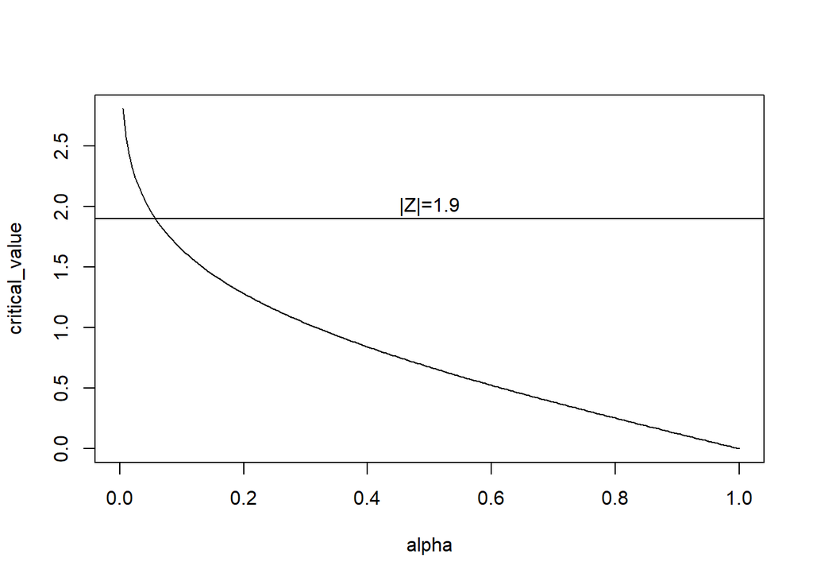

```r
x = 140
n = 250
p0 = 1/2
alpha = seq(0,1,0.005)
z = abs((x - n*p0)/sqrt(n*p0*(1-p0)))
critical_value = qnorm(1-alpha/2)
plot(alpha, critical_value, type='l')
abline(h=z)
text(x=0.5, y = 2, labels="|Z|=1.9")
```

```r
reject = z>critical_value
head(data.frame(alpha, z, critical_value, reject), 20)
```

```
##    alpha        z critical_value reject
## 1  0.000 1.897367            Inf  FALSE
## 2  0.005 1.897367       2.807034  FALSE
## 3  0.010 1.897367       2.575829  FALSE
## 4  0.015 1.897367       2.432379  FALSE
## 5  0.020 1.897367       2.326348  FALSE
## 6  0.025 1.897367       2.241403  FALSE
## 7  0.030 1.897367       2.170090  FALSE
## 8  0.035 1.897367       2.108358  FALSE
## 9  0.040 1.897367       2.053749  FALSE
## 10 0.045 1.897367       2.004654  FALSE
## 11 0.050 1.897367       1.959964  FALSE
## 12 0.055 1.897367       1.918876  FALSE
## 13 0.060 1.897367       1.880794   TRUE
## 14 0.065 1.897367       1.845258   TRUE
## 15 0.070 1.897367       1.811911   TRUE
## 16 0.075 1.897367       1.780464   TRUE
## 17 0.080 1.897367       1.750686   TRUE
## 18 0.085 1.897367       1.722384   TRUE
## 19 0.090 1.897367       1.695398   TRUE
## 20 0.095 1.897367       1.669593   TRUE
```

$~$

#### 11.2.0.1 Exercise

In the plot and the table we see that there is an inverse (decreasing) relationship between the level of significance ($\alpha$) and the critical value. The smaller $\alpha$, the larger the critical value. Explain why.

**Click for the answer**

Choosing $\alpha$ to be small means that we want to ensure a small probability of a type I error. The only way to achieve this, is to set the critical value so high that there is a small probability of rejecting the null hypothesis.

So: Testing at a small level of significance is more strict than testing at higher level. That is, we need more evidence (in the form of a larger test statistic) to reject the null-hypothesis.

$~$

Since there is an decreasing relationship between the level of significance and the critical value, it follows that there is exactly one $\alpha$ at which they are equal and the test decision changes. We call this value for $\alpha$ the “marginal level of significance”, or the *p-value*.

> The p-value is the smallest level of significance at which someone using a particular test statistic would reject the null hypothesis on the basis of the observed data.

```r
margin = function(alpha) z - qnorm(1-alpha/2)   # = 1.9 - critical_value
uniroot(margin, c(0,1))$root                    # p-value
```

```
## [1] 0.05778042
```

$~$

#### 11.2.0.2 Exercise

It follows directly from our definition that we reject the null hypothesis if and only if the p-value is smaller than the level of significance. Explain in your own words.

**Click for the answer**

The p-value is the smallest level of significance at which we would reject. So, at significance levels above the p-value we would reject, while below the p-value we wouldn’t.

$~$

The p-value is a *measure of evidence against $H_0$*. Why? Because the smaller the $\alpha$-level, the more evidence against $H_0$ we require before we are willing to reject $H_0$. A small p-value, say 0.001, means that even if we would have taken a stringent approach to evidence with $\alpha=0.005$, we would still have rejected $H_0$. Note the “what-if” type of phrasing here! Of course, it makes no sense to choose the $\alpha$-level after seeing the $p$-value, so the $p$-value is *not* the type I error of the test.

$~$

The p-value is a number between zero and one, and a small p-value is evidence against the null hypothesis. This leads many people to believe that the p-value is the probability that $H_0$ is true. This is absolutely not so! Finding a p-value of, say, 0.057 simply means that if you had set the level of significance at 0.057 (instead of 0.05) then your result would be (just) significant.

$~$

The p-value is also not the probability that the experimental result to “due to pure chance” or any other nonsense like that.

$~$

#### 11.2.0.3 Exercise

Why is the p-value not the probability that $H_0$ is true?

**Click for the answer**

It helps to consider what “the probability that the null hypothesis is true” actually means. To speak of this probability, we must be able to think of the truth of the null hypothesis as something random. This is not what we have done so far. $H_0: \theta =\theta_0$ is a statement that either is true or false; it is not a random variable. In the *frequentist* framework we have introduced so far “the probability that the null hypothesis is true” is not defined. It can be defined, however, if you take the so-called *Bayesian* perspective. This will be discussed in the Bayesian statistics course.

$~$

Let’s compute the p-value in another example. Suppose we want to do a one-sided Wald test for $H_0:\lambda=1$ versus the alternative $H_1 : \lambda > 1$ in a Poisson model. We observe $X = (0, 3, 3, 4, 2, 0, 1, 4, 0, 4)$. We can calculate the p-value as follows.

```r
library(numDeriv)
X = c(0, 3, 3, 4, 2, 0, 1, 4, 0, 4)
N = length(X)
lambda_0 = 1
loglik_fun = function(lambda) sum(dpois(X, lambda=lambda, log=TRUE))
hat_lambda = optimize(loglik_fun, c(0,6), maximum = TRUE)$maximum  # compute the MLE (it's actually mean(X))
test_statistic = hat_lambda - lambda_0
Fisher_info=-hessian(loglik_fun,hat_lambda)   # compute the Fisher info (it's actually N/hat_lambda)
critical_value = function(alpha) qnorm(1-alpha, sd=1/sqrt(Fisher_info))
margin = function(alpha) test_statistic - critical_value(alpha)
uniroot(margin, c(0,1))$root    # p-value
```

```
## [1] 0.008191373
```

$~$

#### 11.2.0.4 Exercise

Suppose we have observed $X=(1.0,5.2,2.1,9.3,0.7,1.5,2.5,0.9,1.0,3.8,6.6,1.6)$ from an exponential distribution with unknown rate $\lambda$. We want to do a two-sided Wald test of $H_0 : \lambda=0.5$ versus the alternative $H_1 : \lambda \neq 0.5$.

1. Compute the MLE
2. Compute the Fisher information.
3. Compute the p-value.

**Click for the answer**

```r
X=c(1.0,5.2,2.1,9.3,0.7,1.5,2.5,0.9,1.0,3.8,6.6,1.6)
N=length(X)
lambda_0 = 0.5
loglik_fun = function(lambda) sum(dexp(X, rate=lambda, log=TRUE))
hat_lambda = optimize(loglik_fun, c(0,2), maximum = TRUE)$maximum  # compute the MLE (it's actually 1/mean(X))
test_statistic = abs(hat_lambda - lambda_0)
Fisher_info=-hessian(loglik_fun,hat_lambda)   # compute the Fisher info (it's actually N/hat_lambda^2)
critical_value = function(alpha) qnorm(1-alpha/2, sd=1/sqrt(Fisher_info))
margin = function(alpha) test_statistic - critical_value(alpha)
uniroot(margin, c(0,1))$root
```

```
## [1] 0.07826178
```

$~$

## 11.3 The p-value as a tail probability

Using uniroot is not the most efficient way to compute the p-value. It is better to compute it as follows (revisiting the Poisson example above):

```r
X = c(0, 3, 3, 4, 2, 0, 1, 4, 0, 4)
N = length(X)
lambda_0 = 1
loglik_fun = function(lambda) sum(dpois(X, lambda=lambda, log=TRUE))
hat_lambda = optimize(loglik_fun, c(0,6), maximum = TRUE)$maximum  # compute the MLE (it's actually mean(X))
test_statistic = hat_lambda - lambda_0
Fisher_info=-hessian(loglik_fun,hat_lambda)    # compute the Fisher info (it's actually N/hat_lambda)

# instead of uniroot, now use this:
1 - pnorm(test_statistic, sd=1/sqrt(Fisher_info))
```

```
## [1] 0.008188686
```

Why can we compute the p-value in this way? Recall that the p-value is the marginal significance level. In other words, it is the significance level at which the decision reject/don’t reject changes. But this happens precisely when the test statistic is equal to the critical value. We have used uniroot to find the value for $\alpha$ where this happens.

Now, the p-value is defined as the level of significance of a test whose critical value happens to be equal to the observed test statistic. This particular significance level is the probability, under the null hypothesis, that the test statistic exceeds the observed value. In the code above, we simply computed this probability directly.

In terms of mathematics, we have the following. Suppose that under the null-hypothesis a test statistic $T$ has cumulative distribution function $F$. Then the p-value is given by $p=1-F(T)$. (Don’t confuse this $p$ with the probability of a success in de Belgian euro experiment!)

In light of this computation, the p-value is sometimes described as: *the probability that the test statistic exceeds its observed value, if the null hypothesis is true.* This description is very helpful when you want to compute a p-value, but it is not helpful at all when you want to understand what it is. It’s actually quite misleading. To interpret the p-value, you should simply think of it as the “marginal level of significance”.

$~$

#### 11.3.0.1 Exercise

Calculate the p-value of the Belgian euro experiment again, but now using pnorm instead of uniroot.

**Click for the answer**

```r
x = 140
n = 250
p0 = 1/2
alpha = seq(0,1,0.005)
z = (x - n*p0)/sqrt(n*p0*(1-p0))
test_statistic=abs(z)         # observed value of the test statistic (|z|=1.9)
pnorm(-test_statistic) + 1 - pnorm(test_statistic)     # p-value = P(|Z|>1.9)
```

```
## [1] 0.05777957
```

Alternatively,

```r
2*pnorm(-test_statistic)
```

```
## [1] 0.05777957
```

$~$

#### 11.3.0.2 Exercise

Suppose we want to do a two-sided likelihood ratio test for $H_0:\lambda=1$ versus the alternative $H_1 : \lambda \neq 1$ in a Poisson model. Use the asymptotic distribution of the likelihood ratio statistic. We observe $X = (0, 3, 3, 4, 2, 0, 1, 4, 0, 4)$. Use both uniroot and the direct calculation to get the p-value, and verify that they give (approximately) the same result.

**Click for the answer**

In this case, two times the log likelihood ratio has the chi-squared distribution with one degree of freedom (asympotically) under the null hypothesis.

```r
X = c(0, 3, 3, 4, 2, 0, 1, 4, 0, 4)
lambda_0 = 1
loglik_fun = function(lambda) sum(dpois(X, lambda=lambda, log=TRUE))
hat_lambda = optimize(loglik_fun, c(0,6), maximum = TRUE)$maximum
test_statistic = 2*(loglik_fun(hat_lambda) - loglik_fun(lambda_0))  # 2 x log likelihood ratio
critical_value = function(alpha) qchisq(1-alpha, df=1)
margin = function(alpha) test_statistic - critical_value(alpha)
uniroot(margin, c(0,1))$root
```

```
## [1] 0.00248791
```

```r
1 - pchisq(test_statistic, df=1)
```

```
## [1] 0.002471777
```

$~$

We will now revisit a few exercises from day 8.

#### 11.3.0.3 Exercise

Suppose that 160 patients are divided randomly into two groups of 80. The patients in the first group are given some treatment, and 30 of the 80 recover from their illness. In the other group, the patients are given a placebo, and only 20 recover. So, we have the following 2x2 table

```r
Observed = matrix(c(30,50,20,60),nrow=2,byrow=TRUE)
Observed
```

```
##      [,1] [,2]
## [1,]   30   50
## [2,]   20   60
```

We can use the chi-squared test for the null-hypothesis that there is no difference between the treatment and placebo. Compute the p-value by calculating the appropriate tail probability.

**Click for the answer**

Under the null hypothesis (no difference) we estimate the probability of recovery at p=50/160. So, the 2x2 table of *expected* counts is

```r
p=50/160
Expected = matrix(c(80*p,80*(1-p),80*p,80*(1-p)),nrow=2,byrow=TRUE)
Expected
```

```
##      [,1] [,2]
## [1,]   25   55
## [2,]   25   55
```

The chi-squared statistic is

```r
X2=sum((Observed - Expected)^2/Expected)
X2
```

```
## [1] 2.909091
```

Under the null-hypothesis, X2 has the chi-squared ditribution with 1 degree of freedom. So, the p-value is

```r
1-pchisq(X2,1)
```

```
## [1] 0.08808151
```

We do not reject $H_0$ at the 5% level.

$~$

#### 11.3.0.4 Exercise

Suppose a supermarket sells potatoes in 1 kilo bags. We buy 7 bags and weigh them. We find 983, 1041, 1026, 1025, 1033, 968 and 1028 (grams). We know that the standard deviation of the weight is 25 grams. We want to test
$$H_0 : \mu = 1000 \quad \text{versus}\quad A : \mu \neq 1000$$
Compute the p-value by calculating the appropriate tail probability.

**Click for the answer**

The Z statistic is

```r
x=c(983,1041,1026,1025,1033,968,1028)
z=sqrt(7)*(mean(x)-1000)/25            # n=7, sd=25
z
```

```
## [1] 1.572332
```

Under the null hypothesis, z has the standard normal distribution. So, the p-value is

```r
2*pnorm(-abs(z))
```

```
## [1] 0.1158735
```

We do not reject $H_0$ at the 5% level.

$~$

#### 11.3.0.5 Exercise

Now, we have long suspected that the supermarket is cheating by putting on average *less* than 1 kilo in their bags.What is the p-value of the appropriate one-sided test?

**Click for the answer**

The Z statistic is

```r
x=c(983,1041,1026,1025,1033,968,1028)
z=sqrt(7)*(mean(x)-1000)/25            # n=7, sd=25
z
```

```
## [1] 1.572332
```

Under the null hypothesis, z has the standard normal distribution. Now we reject only when $z$ is too small. So, the p-value is

```r
pnorm(z)
```

```
## [1] 0.9420632
```

We do not reject $H_0$ at the 5% level.

$~$

## 11.4 Monte-Carlo computation of the p-value

So far we have used the asymptotic distribution. We can also calculate exact p-values numerically. If we simulated test statistics from the distribution under the null hypothesis, the p-value is the probability mass of the null distribution that is more extreme than the observed statistic, which is simply the number of simulated test statistics that exceed the observed value.

We demonstrate this approach by calculating the p-value for the Belgian euro example using the simulated null distribution of the absolute difference between the number of heads and 125.

Since we don’t have to worry about the theoretical distribution of the test statistic under $H_0$, we might as well use the intuitive $|X-125|$.

```r
X = 140
N = 250
p_0 = 1/2
test_statistic=abs(X-125)
X=rbinom(10^5,size=N,p=p_0)   # sampling under the null hypothesis
null_statistics=abs(X-125)
mean(null_statistics >= test_statistic)  # p-value
```

```
## [1] 0.06683
```

As always, note how simple this is! We *only* need to be able to sample data under the null hypothesis. It does not matter how simple or complicated the test statistic is.

Compare this result to the p-value of 0.057 which we got by using the normal approximation of the binomial distribution. In this very simple example we can also compute the p-value exactly:

```r
X = 140
N = 250
p_0 = 1/2
pbinom(110,size=N,p=p_0) + 1 - pbinom(139,size=N,p=p_0)
```

```
## [1] 0.06642115
```

$~$

#### 11.4.0.1 Exercise

Why 139 and not 140?

**Click for the answer**

$~$

#### 11.4.0.2 Exercise

Suppose we want to do a two-sided Wald test for $H_0:\lambda=1$ versus the alternative $H_1 : \lambda \neq 1$ in a Poisson model. Use the simulated distribution of the test statistic. To avoid repeatedly using the optimize function, you can use that the MLE of $\lambda$ is just the average $\bar X$. Suppose we observe $X = (0, 3, 3, 4, 2, 0, 1, 4, 0, 4)$.

**Click for the answer**

```r
X = c(0, 3, 3, 4, 2, 0, 1, 4, 0, 4)
N = length(X)
lambda_0 = 1
hat_lambda = mean(X)                        # MLE
test_statistic = abs(hat_lambda - lambda_0) # Wald statistic
null_statistics = replicate( 1e5, {
  X = rpois(N, lambda=lambda_0)    # sampling under the null hypothesis
  abs(mean(X) - lambda_0)
})
mean(null_statistics >= test_statistic)  # p-value
```

```
## [1] 0.00168
```

$~$

#### 11.4.0.3 Exercise

Now calculate the p-value of the likelihood ratio test for the Poisson problem using the simulated null distribution of the likelihood ratio statistic.

**Click for the answer**

```r
X = c(0, 3, 3, 4, 2, 0, 1, 4, 0, 4)
N = length(X)
lambda_0 = 1
loglik_fun = function(lambda) sum(dpois(X, lambda=lambda, log=TRUE))
hat_lambda = mean(X) # MLE
test_statistic = 2*(loglik_fun(hat_lambda) - loglik_fun(lambda_0))  # lik. ratio statistic
null_statistics = replicate( 1e5, {
  X = rpois(N, lambda=lambda_0)   # sampling under the null hypothesis
  loglik_fun = function(lambda) sum(dpois(X, lambda=lambda, log=TRUE))
  hat_lambda = mean(X)
  2*(loglik_fun(hat_lambda) - loglik_fun(lambda_0))
})
mean(null_statistics >= test_statistic)  # p-value
```

```
## [1] 0.00384
```

$~$

#### 11.4.0.4 Exercise

Suppose we have a sample of size $n = 5$ from the normal distribution with mean $\mu = 0$ and unknown standard deviation $\sigma$. Suppose we decide to test
$$H_0 : \sigma = 2 \quad {\rm versus}\quad A: \sigma > 2.$$
by computing the sample standard deviation $S$, and rejecting $H_0$ if $S$ is large. Suppose we find that $S=3.6$. Use simulation to determine the p-value.

**Click for the answer**

```r
test_statistic = 3.6
null_statistics = replicate( 1e5, {
  X = rnorm(5, mean=0, sd=2)   # sampling under the null hypothesis
  sd(X)
})
mean(null_statistics >= test_statistic)  # p-value
```

```
## [1] 0.01253
```

$~$

#### 11.4.0.5 Exercise

Suppose we have a random sample of size $n$ = 12 and want to test the (null) hypothesis that they were drawn from the normal distribution with mean 1 and standard deviation 1 versus the alternative that they were drawn from the exponential distribution with mean 1. We know that the normal distribution is symmetric, so that the (population) mean and de median are equal. The exponential distribution, however, is skewed to the right so that the mean is larger than the median. So, we decide to use the following test: Compute the sample mean $\bar x$ and the sample median $m$, and reject the null hypothesis if $T=\bar x - m$ is large. Suppose we observe $T=0.5$.

1. Use simulation to determine the p-value.
2. Make a histogram of the simulated test statistics and compare to the observed $T=0.5$

**Click for the answer**

```r
test_statistic = 0.5
null_statistics = replicate( 1e5, {
  X = rnorm(12, mean=1, sd=1)   # sampling under the null hypothesis
  mean(X) - median(X)
})
mean(null_statistics >= test_statistic)  # p-value
```

```
## [1] 0.00432
```

So, the difference between the sample mean and the sample median is larger than we would expect if the data were sampled from a normal distribution with mean and standard deviation one.

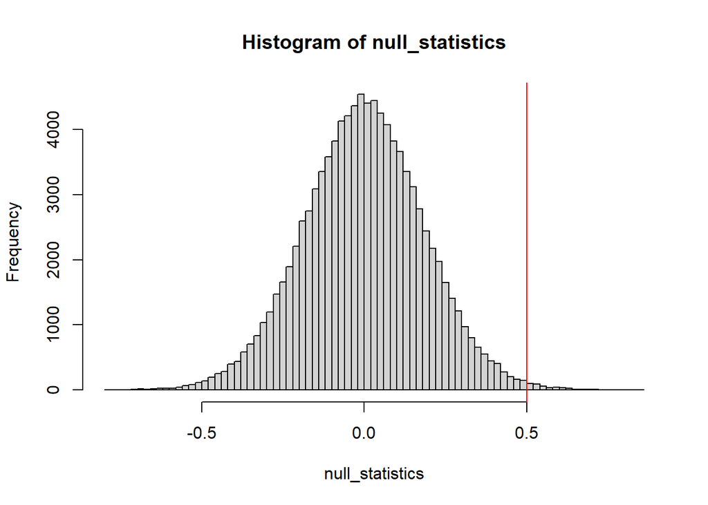

```r
hist(null_statistics,100)
abline(v=0.5,col="red")
```

$~$

## 11.5 The sampling distribution of the p-value

The p-value is a function of the data, and therefore a random variable. What is the distribution of the p-value under the null hypothesis? Let’s try a Wald test in an exponential model and look at the distribution under $H_0$.

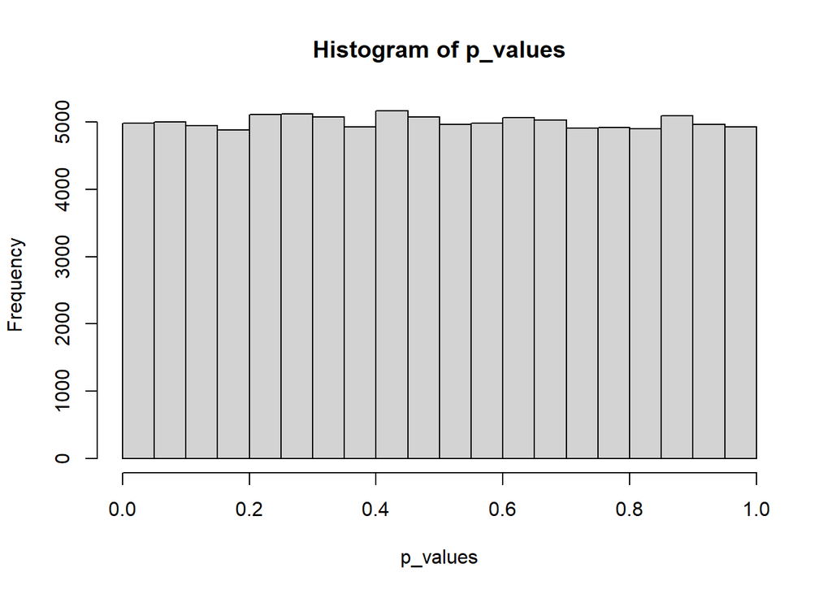

```r
lambda0 = 1/4
N = 100
p_values = replicate( 1e5, {
  X = rexp(N, rate=lambda0)
  hat_lambda = 1/mean(X)
  T_Wald = hat_lambda - lambda0
  FisherInfo = N/hat_lambda^2
  2*pnorm(-abs(T_Wald), mean=0, sd=sqrt(1/FisherInfo))
})
hist(p_values)
```

We recognize the (standard) uniform distribution. This holds in general; the null distribution of a p-value is uniform. We can see that analytically as follows. If the test statistic has cumulative distribution function (CDF) $F$, then $p=1-F(T)$ is the p-value. We can now derive the CDF of the p-value $p$ and then we find that it is the CDF of the standard uniform distribution. For $0 \leq x \leq 1$, we have

$$\begin{align*}
\mathrm{P}(p \leq x) &= \mathrm{P}(1-F(T) \leq x)\\
&= \mathrm{P}(F(T) \geq 1-x) \\
&= \mathrm{P}(T \geq F^{-1}(1-x)) \\
&= 1-\mathrm{P}(T \leq F^{-1}(1-x))\\
&=1-F(F^{-1}(1-x)) \\
&= 1-(1-x)= x.
\end{align*}$$

This is indeed the cumulative distribution function of the standard uniform distribution.

Since $p=1-F(T)$ is simply a transformation of the test statistic $T$, we can also view the p-value as a test statistic. Of course, if we use the p-value as a test statistic, we must reject for small values, rather than large ones.

The attractiveness of using the p-value as a test statistic, lies in the fact that is has such a simple null distribution and therefore such a simple critical value, namely $\alpha$ itself.

> A p-value is a transformed test statistic for $H_0$ that has a uniform (0,1) distribution under $H_0$.

The uniform distribution is only *approximate* if we use the asymptotic distribution of the test statistic, or if the test statistic is discrete.

$~$

#### 11.5.0.1 Exercise

Make histograms of the null distribution of the p-values for the asymptotic likelihood ratio test of $H_0: \lambda = 1/4$ in a an exponential model with $N=3$ and $N=40$.

**Click for the answer**

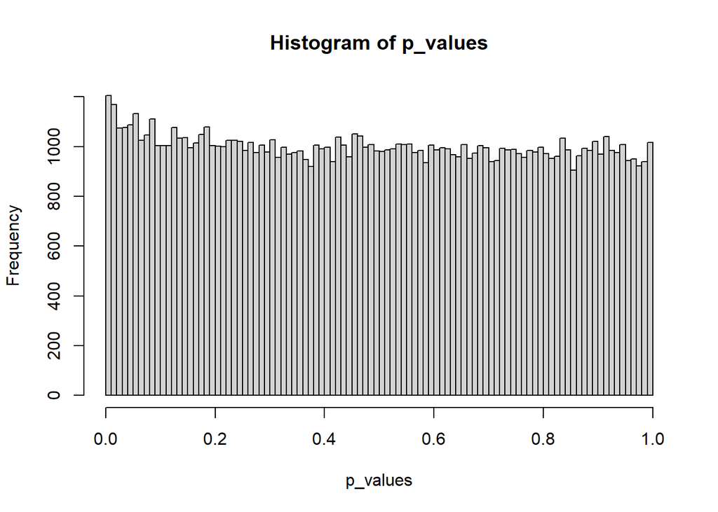

```r
lambda_0 = 1/4
N = 3
p_values = replicate( 1e5, {
  X = rexp(N, rate=lambda0)
  hat_lambda = 1/mean(X)
  loglik_fun = function(lambda) sum(dexp(X, rate = lambda, log=TRUE))
  test_statistic = 2*(loglik_fun(hat_lambda) - loglik_fun(lambda_0))
  1 - pchisq(test_statistic, df=1)
})
hist(p_values,100)
```

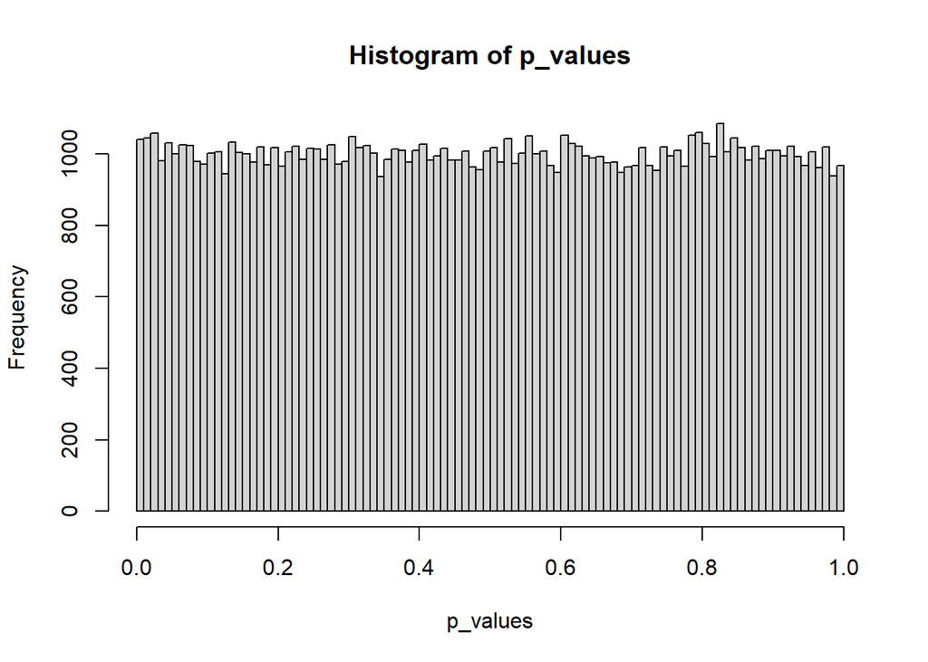

```r
lambda_0 = 1/4
N = 40
p_values = replicate( 1e5, {
  X = rexp(N, rate=lambda0)
  hat_lambda = 1/mean(X)
  loglik_fun = function(lambda) sum(dexp(X, rate = lambda, log=TRUE))
  test_statistic = 2*(loglik_fun(hat_lambda) - loglik_fun(lambda_0))
  1 - pchisq(test_statistic, df=1)
})
hist(p_values,100)
```

The distribution is noticeably closer to uniform when the sample size is larger. This is especially clear at lower p-values and that is also where it is more relevant.

$~$

## 11.6 Criticism of the p-value

First of all, there is nothing wrong with the p-value in and of itself. The math is all correct and it does what it is supposed to do. Still there is much discussion about the and improper use of the p-value (or rather, hypothesis testing in general). American Statistical Association, confusingly, issued a [statement](https://www.tandfonline.com/doi/full/10.1080/00031305.2016.1154108) in 2016 to warn against the over-interpretation of statistical significance, followed in 2021 by another [statement](https://hdsr.mitpress.mit.edu/pub/50vl2b07/release/2) endorsing the p-value.

The criticism roughly concerns the following four points.

1. *Interpretation* As we discussed, the interpretation of p-values is quite subtle. Users tend to misinterpret the p-value as the probability that the null hypothesis is true, or the probability that the data are random, or such things. See Steven Goodman’s [dirty dozen](http://osdm.org/wp-content/uploads/2017/01/v8740.pdf) or Sander Greenland’s [guide to misinterpretation](https://link.springer.com/article/10.1007/s10654-016-0149-3) for nice discussions.
2. *The replication crisis* A statistical hypothesis test at level $\alpha$ is set up in such a way that the probability of a type I error (reject the null hypothesis when it is actually true) does not exceed $\alpha$. That’s the math and it is entirely correct. Unfortunately, the *reality* is that statistical tests are vulnerable to cheating. For example, one can easily get $p<0.05$ by manipulating the data in various ways (leaving out “outliers”, transforming variables or other forms of pre-processing), trying out many different models and tests (“p-hacking”), or testing many hypotheses and only reporting the significant ones (“fishing”). The results of such “analyses” will typically not replicate in the sense that if other researchers try to repeat the experiment they will not find similar results. Much has been written about this [replication crisis in science](https://journals.plos.org/plosmedicine/article?id=10.1371/journal.pmed.0020124). Justifiably or not, the p-value is often blamed for this mess, see for example this article in [Nature](https://www.nature.com/articles/d41586-019-00857-9) in which the authors “call for the entire concept of statistical significance to be abandoned.”
3. *Dichotomous thinking* A “dichotomy” is a division or contrast between two things that are or are represented as being opposed or entirely different. Statistical tests in general, and p-values in particular, are said to encourage dichotomous thinking. Users will think that $p<0.05$ implies that the null-hypothesis is false and that $p>0.05$ means it is true. In fact, the distinction is not that clear-cut because [the difference between “significant” and “not significant” is not itself statistically significant](http://www.stat.columbia.edu/~gelman/research/unpublished/signif3.pdf). For example, Consider two independent studies with effect estimates and standard errors of 25 $\pm$ 10 and 10 $\pm$ 10. The first study is statistically significant at the 1% level, and the second is not at all statistically significant, being only one standard error away from zero. Thus, it would be tempting to conclude that there is a large difference between the two studies. In fact, however, the difference is not even close to being statistically significant: the estimated difference is 15, with a standard error of $\sqrt{10^2 + 10^2}=14$.
4. *The file drawer* The idea that results that are not statistically significant are not useful and not worthy of publication has distorted the scientific literature. Below is a histogram of more than one million z-values (converted from p-values) from the Medline archive. As we know, z-values between -2 and 2 are not significant at the 5% level. Clearly, they are largely missing from the published record. They ended up collecting dust in the researcher’s proverbial “file drawer”. As a result, the scientific literature *appears* much more successful than it actually is.

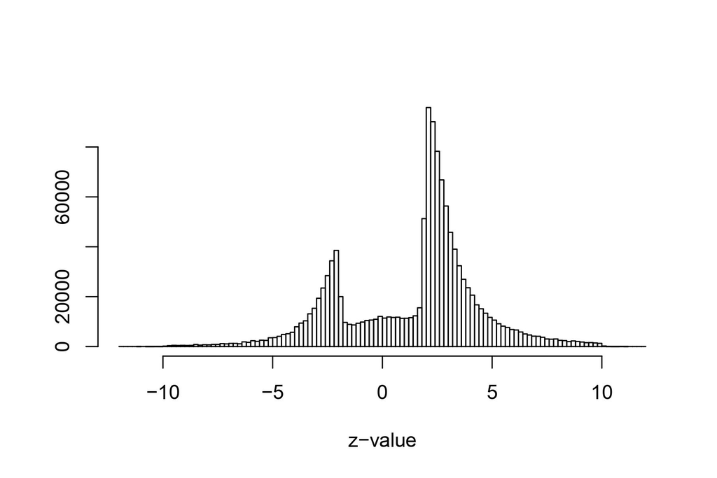

Note that, though there are many critics of the p-value, almost no two critics agree on an alternative, since most alternatives share some of the drawbacks of the p-value, or introduce novel drawbacks of their own. The discussion continues!

Recall what sir Ronald Fisher said:

> If one in twenty does not seem high enough odds, we may, if we prefer it, draw the line at one in fifty (the 2 per cent point), or one in a hundred (the 1 per cent point). Personally, the writer prefers to set a low standard of significance at the 5 per cent point, and ignore entirely all results which fail to reach this level.

These words have had quite an impact over the last century!

## 11.7 What have we learned

- We can explain the p-value as a marginal significance level.
- We can calculate p-values as a tail probability.
- We know the null distribution of a p-value.
- We can interpret a p-value as a test statistic.